# When the definition of neighbour changes spatial reality

Skip to the reportLangsung ke laporan

Spatial Weights Critique Interactive dashboardDashboard interaktif

Columbus, Ohio / 1980

A critique of Moran’s I, Geary’s C and LISAKritik terhadap Moran’s I, Geary’s C, dan LISA

# When the definition of neighbour changes spatial realityKetika definisi tetangga mengubah realitas spasial

Residential burglaries and vehicle thefts, combined, per 1,000 householdsPencurian rumah dan kendaraan, digabung, per 1.000 rumah tangga

49 neighbourhoods of Columbus, Ohio, in 1980. The data never change. Only the rule for who counts as a neighbour changes, 32 times. This report measures how much the answer moves, and which rule to use when nothing else is known.49 lingkungan di Columbus, Ohio, tahun 1980. Datanya tidak pernah berubah. Yang berubah hanya aturan siapa yang dihitung sebagai tetangga, sebanyak 32 kali. Laporan ini mengukur seberapa jauh jawabannya bergeser, dan aturan mana yang dipakai bila tidak ada informasi lain.

**Febrianggi Caesar Immanuel** Statistics, Universitas Padjadjaran.Statistika, Universitas Padjadjaran. Knitted 2026-11-21.Di-knit 21-11-2026.

## Why this report existsMengapa laporan ini dibuat

Moran’s I, Geary’s C and LISA cluster maps are easy to compute and easy to misuse. Each of them needs a spatial weights matrix $W$: a rule that says which areas are neighbours and how much each neighbour counts. The analyst chooses that rule, and the software accepts any choice. When $W$ is picked after the output has been seen, the reported result says as much about the search as about the data. This is called specification searching.

This report is a critique, not a showcase. The data stay fixed (CRIME in Columbus) and only $W$ changes, 32 times. The question is not “is crime clustered?” but “how much of the answer is made by the definition of neighbour?”.

Moran’s I, Geary’s C, dan peta klaster LISA mudah dihitung dan mudah disalahgunakan. Semuanya membutuhkan matriks bobot spasial $W$: aturan yang menentukan wilayah mana yang bertetangga dan seberapa besar bobot tiap tetangga. Aturan itu dipilih oleh analis, dan perangkat lunak menerima pilihan apa pun. Bila $W$ dipilih setelah hasilnya terlihat, hasil yang dilaporkan lebih banyak bercerita tentang proses pencarian daripada tentang data. Praktik ini disebut *specification searching*.

Laporan ini adalah kritik, bukan etalase. Datanya tetap (CRIME di Columbus) dan hanya $W$ yang diganti, sebanyak 32 kali. Pertanyaannya bukan “apakah kejahatan mengelompok?”, melainkan “seberapa besar jawaban itu dibentuk oleh definisi tetangga?”.

1. 010.153 to 0.6070,153 s.d. 0,607

   Moran’s I for the same CRIME values, depending only on W (lowest under 1/d · W, highest under k = 2 · B).Moran’s I untuk nilai CRIME yang sama, hanya bergantung pada W (terendah pada 1/d · W, tertinggi pada k = 2 · B).
2. 020 to 300 s.d. 30

   Neighbourhoods with a significant local Moran statistic after 5% FDR correction, High-High and Low-Low clusters and High-Low and Low-High outliers together. Queen · W finds 4; 6 of the 32 matrices find none.Lingkungan dengan statistik Moran lokal yang signifikan setelah koreksi FDR 5%, klaster Tinggi-Tinggi dan Rendah-Rendah serta pencilan Tinggi-Rendah dan Rendah-Tinggi digabung. Queen · W menemukan 4; 6 dari 32 matriks tidak menemukan satu pun.
3. 030.515 → −0.0250,515 → −0,025

   Moran’s I with Queen neighbours, then with the same number of neighbours assigned at random. Placement drives the result.Moran’s I dengan tetangga Queen, lalu dengan jumlah tetangga yang sama tetapi diacak. Letak bobot yang menentukan hasil.
4. 041/d · W1/d · W

   Recommended when nothing is known about the spatial process: the smallest worst-case loss of power (0.122) in the simulation.Rekomendasi bila proses spasialnya tidak diketahui: kehilangan daya terburuk paling kecil (0,122) dalam simulasi.

What a good-looking result does not proveHal yang tidak dibuktikan oleh hasil yang terlihat bagus

A small p-value under one $W$ shows that this $W$ found structure in these data. It does not show that the structure survives another reasonable $W$, that the $W$ was chosen for a reason, or that a LISA cluster is real after testing 49 areas at once. Each of these claims needs its own evidence, and the chapters below supply it for CRIME.

p-value kecil pada satu $W$ hanya menunjukkan bahwa $W$ itu menemukan struktur pada data ini. Itu tidak menunjukkan bahwa struktur tersebut bertahan pada $W$ lain yang juga masuk akal, bahwa $W$ dipilih dengan alasan, atau bahwa klaster LISA tetap nyata setelah 49 wilayah diuji sekaligus. Setiap klaim itu membutuhkan buktinya sendiri, dan bab-bab berikut menyediakannya untuk CRIME.

The study computed the same pipeline for six Columbus variables; their full results are in `output/csv/` and in the dashboard. This report reads only CRIME, as the revision asked, so that every chart and table follows one variable from start to finish.

Pipeline yang sama dijalankan untuk enam variabel Columbus; hasil lengkapnya ada di `output/csv/` dan di dashboard. Laporan ini hanya membaca CRIME, sesuai permintaan revisi, sehingga setiap grafik dan tabel mengikuti satu variabel dari awal sampai akhir.

## The dataData

CRIME is the number of residential burglaries and vehicle thefts per 1,000 households in each of the 49 planning neighbourhoods of Columbus, Ohio, in 1980 (Anselin, 1988, Table 12.1). The file used here is the GeoDa/SAL shapefile. It was checked against the copy in the R package `spData`: attributes and vertex coordinates are identical, there are no missing values, and all nine required validation checks pass. The file has no coordinate reference system, so distances below are in map units.

CRIME adalah jumlah pencurian rumah dan kendaraan per 1.000 rumah tangga di setiap 49 lingkungan perencanaan Columbus, Ohio, tahun 1980 (Anselin, 1988, Tabel 12.1). Berkas yang dipakai adalah shapefile GeoDa/SAL. Berkas ini dicocokkan dengan salinan di paket R `spData`: atribut dan koordinat verteksnya identik, tidak ada nilai hilang, dan kesembilan pemeriksaan validasi wajib lolos. Berkas ini tidak memiliki sistem referensi koordinat, sehingga jarak di bawah memakai satuan peta.

CRIME at a glance (49 neighbourhoods)

| Statistic | CRIME |
| --- | --- |
| n | 49 |
| Mean | 35.13 |
| Standard deviation | 16.73 |
| Min | 0.18 |
| Q1 | 20.05 |
| Median | 34.00 |
| Q3 | 48.59 |
| Max | 68.89 |
| Skewness | 0.03 |
| Excess kurtosis | −0.77 |
| Shapiro–Wilk p | 0.296 |
| Outliers (1.5 · IQR) | 0 |

Ringkasan CRIME (49 lingkungan)

| Statistik | CRIME |
| --- | --- |
| n | 49 |
| Rata-rata | 35,13 |
| Simpangan baku | 16,73 |
| Min | 0,18 |
| Q1 | 20,05 |
| Median | 34,00 |
| Q3 | 48,59 |
| Maks | 68,89 |
| Kemencengan | 0,03 |
| Kurtosis berlebih | −0,77 |
| p Shapiro–Wilk | 0,296 |
| Pencilan (1,5 · IQR) | 0 |

Figure 1Gambar 1Where CRIME is highDi mana CRIME tinggi

[figure not shown]

**Residential burglaries and vehicle thefts per 1,000 households, quintiles**0.2 – 19.019.0 – 29.329.3 – 39.039.0 – 53.253.2 – 68.9

[figure not shown]

**Pencurian rumah dan kendaraan per 1.000 rumah tangga, kuintil**0,2 – 19,019,0 – 29,329,3 – 39,039,0 – 53,253,2 – 68,9

Quintiles of CRIME per 1,000 households. Hover a neighbourhood to see its POLYID and value. The highest values form a block in the centre of the city and fall off toward the edges. That is the pattern every statistic below tries to summarise.Kuintil CRIME per 1.000 rumah tangga. Arahkan kursor ke lingkungan untuk melihat POLYID dan nilainya. Nilai tertinggi membentuk satu blok di tengah kota dan menurun ke arah pinggiran. Pola inilah yang coba diringkas oleh setiap statistik di bawah.

## 32 definitions of neighbour32 definisi tetangga

Each matrix is built from one of four rules, at several settings, and then used either as binary weights (B: every neighbour counts 1) or row-standardised (W: each row sums to 1, so a neighbourhood’s neighbours share one unit of weight). Inverse-distance matrices use raw weights $1/d$ or $1/d^2$ instead of binary ones.

- **Contiguity:** Queen (shares a border or a corner) and Rook (shares a border).
- **K nearest neighbours:** $k$ = 2, 3, 4, 5, 6, 8 closest centroids.
- **Distance band:** every centroid within $d$ map units, for $d$ from 0.62 (the smallest value that leaves nobody isolated) to 1.65.
- **Inverse distance:** every pair weighted by $1/d$ or $1/d^2$.

The diagonal is zero in all 32 ($w_{ii} = 0$): an area is never its own neighbour. Chapter 8 shows why this matters. The Queen matrix reproduces the GeoDa `columbus.gal` file exactly.

Setiap matriks dibangun dari salah satu dari empat aturan, dengan beberapa pengaturan, lalu dipakai sebagai bobot biner (B: setiap tetangga bernilai 1) atau distandardisasi baris (W: setiap baris berjumlah 1, sehingga tetangga sebuah lingkungan berbagi satu satuan bobot). Matriks invers jarak memakai bobot mentah $1/d$ atau $1/d^2$, bukan biner.

- **Kontiguitas:** Queen (berbagi batas atau titik sudut) dan Rook (berbagi batas).
- **K tetangga terdekat:** $k$ = 2, 3, 4, 5, 6, 8 centroid terdekat.
- **Pita jarak:** semua centroid dalam radius $d$ satuan peta, dengan $d$ dari 0,62 (nilai terkecil yang membuat tidak ada wilayah terisolasi) sampai 1,65.
- **Invers jarak:** setiap pasangan diberi bobot $1/d$ atau $1/d^2$.

Diagonal bernilai nol pada ke-32 matriks ($w_{ii} = 0$): sebuah wilayah tidak pernah menjadi tetangga dirinya sendiri. Bab 8 menunjukkan mengapa hal ini penting. Matriks Queen identik dengan berkas `columbus.gal` dari GeoDa.

Figure 2Gambar 2Six of the neighbour graphsEnam graf ketetanggaan

#### Queen · B

118 pairs, 4.82 neighbours on average

[figure not shown]

#### k = 2 · B

62 pairs, 2.00 neighbours on average

[figure not shown]

#### k = 6 · B

178 pairs, 6.00 neighbours on average

[figure not shown]

#### d ≤ 0.62 · B

126 pairs, 5.14 neighbours on average

[figure not shown]

#### d ≤ 1.65 · B

584 pairs, 23.84 neighbours on average

[figure not shown]

#### Rook · B

100 pairs, 4.08 neighbours on average

[figure not shown]

#### Queen · B

118 pasangan, rata-rata 4,82 tetangga

[figure not shown]

#### k = 2 · B

62 pasangan, rata-rata 2,00 tetangga

[figure not shown]

#### k = 6 · B

178 pasangan, rata-rata 6,00 tetangga

[figure not shown]

#### d ≤ 0,62 · B

126 pasangan, rata-rata 5,14 tetangga

[figure not shown]

#### d ≤ 1,65 · B

584 pasangan, rata-rata 23,84 tetangga

[figure not shown]

#### Rook · B

100 pasangan, rata-rata 4,08 tetangga

[figure not shown]

Each line joins two neighbourhoods that the rule calls neighbours. The same 49 centroids give anything from a sparse chain (k = 2) to a dense web (d ≤ 1.65). Every statistic in this report is a weighted sum over these lines.Setiap garis menghubungkan dua lingkungan yang oleh aturannya disebut bertetangga. 49 centroid yang sama menghasilkan apa saja, dari rantai jarang (k = 2) sampai jaring padat (d ≤ 1,65). Setiap statistik dalam laporan ini adalah jumlah berbobot atas garis-garis ini.

16 neighbour structures (each used twice: B and W)

| Family | Rule | Directed links | Mean neighbours | Min | Max |
| --- | --- | --- | --- | --- | --- |
| Contiguity | Queen | 236 | 4.82 | 2 | 10 |
| Contiguity | Rook | 200 | 4.08 | 2 | 9 |
| K nearest neighbours | k = 2 | 98 | 2.00 | 2 | 2 |
| K nearest neighbours | k = 3 | 147 | 3.00 | 3 | 3 |
| K nearest neighbours | k = 4 | 196 | 4.00 | 4 | 4 |
| K nearest neighbours | k = 5 | 245 | 5.00 | 5 | 5 |
| K nearest neighbours | k = 6 | 294 | 6.00 | 6 | 6 |
| K nearest neighbours | k = 8 | 392 | 8.00 | 8 | 8 |
| Distance band | d ≤ 0.62 | 252 | 5.14 | 1 | 11 |
| Distance band | d ≤ 0.75 | 346 | 7.06 | 1 | 14 |
| Distance band | d ≤ 0.90 | 488 | 9.96 | 3 | 18 |
| Distance band | d ≤ 1.10 | 656 | 13.39 | 3 | 24 |
| Distance band | d ≤ 1.35 | 876 | 17.88 | 5 | 30 |
| Distance band | d ≤ 1.65 | 1,168 | 23.84 | 5 | 38 |
| Inverse distance | 1/d | 2,352 | 48.00 | 48 | 48 |
| Inverse distance | 1/d² | 2,352 | 48.00 | 48 | 48 |

Inverse distance links every pair, so each area has 48 neighbours with decaying weights.

16 struktur ketetanggaan (masing-masing dipakai dua kali: B dan W)

| Keluarga | Aturan | Link berarah | Rata-rata tetangga | Min | Maks |
| --- | --- | --- | --- | --- | --- |
| Kontiguitas | Queen | 236 | 4,82 | 2 | 10 |
| Kontiguitas | Rook | 200 | 4,08 | 2 | 9 |
| K tetangga terdekat | k = 2 | 98 | 2,00 | 2 | 2 |
| K tetangga terdekat | k = 3 | 147 | 3,00 | 3 | 3 |
| K tetangga terdekat | k = 4 | 196 | 4,00 | 4 | 4 |
| K tetangga terdekat | k = 5 | 245 | 5,00 | 5 | 5 |
| K tetangga terdekat | k = 6 | 294 | 6,00 | 6 | 6 |
| K tetangga terdekat | k = 8 | 392 | 8,00 | 8 | 8 |
| Pita jarak | d ≤ 0,62 | 252 | 5,14 | 1 | 11 |
| Pita jarak | d ≤ 0,75 | 346 | 7,06 | 1 | 14 |
| Pita jarak | d ≤ 0,90 | 488 | 9,96 | 3 | 18 |
| Pita jarak | d ≤ 1,10 | 656 | 13,39 | 3 | 24 |
| Pita jarak | d ≤ 1,35 | 876 | 17,88 | 5 | 30 |
| Pita jarak | d ≤ 1,65 | 1.168 | 23,84 | 5 | 38 |
| Invers jarak | 1/d | 2.352 | 48,00 | 48 | 48 |
| Invers jarak | 1/d² | 2.352 | 48,00 | 48 | 48 |

Invers jarak menghubungkan semua pasangan, sehingga setiap wilayah punya 48 tetangga dengan bobot yang meluruh.

## Global tests under 32 matricesUji global pada 32 matriks

Both indices summarise the whole map in one number. Moran’s I compares each area with its neighbours through cross-products of deviations from the mean. Geary’s C uses squared differences between neighbours, so it reacts more to local jumps:

Kedua indeks meringkas seluruh peta menjadi satu angka. Moran’s I membandingkan setiap wilayah dengan tetangganya melalui perkalian simpangan dari rata-rata. Geary’s C memakai kuadrat selisih antartetangga, sehingga lebih peka terhadap lonjakan lokal:

$$I=\frac{n}{S_0}\,\frac{\sum_i\sum_j w_{ij}(x_i-\bar x)(x_j-\bar x)}{\sum_i (x_i-\bar x)^2},\qquad C=\frac{n-1}{2S_0}\,\frac{\sum_i\sum_j w_{ij}(x_i-x_j)^2}{\sum_i (x_i-\bar x)^2},\qquad S_0=\sum_i\sum_j w_{ij}$$

Positive autocorrelation means $I > E(I) = -1/(n-1)$ and $C < 1$. Significance comes from a permutation test: the 49 CRIME values are shuffled across the map 9,999 times, which destroys any spatial pattern while keeping the values, and the observed index is compared with that shuffled distribution. To put both indices on one scale, z is oriented so that **z > 0 means positive autocorrelation for both**.

Under the reference matrix Queen · W:

Autokorelasi positif berarti $I > E(I) = -1/(n-1)$ dan $C < 1$. Signifikansi diperoleh dari uji permutasi: 49 nilai CRIME diacak posisinya di peta sebanyak 9.999 kali, sehingga pola spasial hilang tetapi nilainya tetap, lalu indeks yang teramati dibandingkan dengan sebaran hasil acakan itu. Agar kedua indeks berada pada satu skala, z diorientasikan sehingga **z > 0 berarti autokorelasi positif untuk keduanya**.

Pada matriks acuan Queen · W:

CRIME under Queen · W, 9,999 permutations

| Index | Value | Expected under H₀ | Permutation z | p (two-sided) | Conclusion |
| --- | --- | --- | --- | --- | --- |
| Moran’s I | 0.500 | −0.021 | 5.60 | < 0.001 | Positive |
| Geary’s C | 0.541 | 1.000 | 4.73 | < 0.001 | Positive |

CRIME dengan Queen · W, 9.999 permutasi

| Indeks | Nilai | Harapan di bawah H₀ | z permutasi | p (dua sisi) | Kesimpulan |
| --- | --- | --- | --- | --- | --- |
| Moran’s I | 0,500 | −0,021 | 5,60 | < 0,001 | Positif |
| Geary’s C | 0,541 | 1,000 | 4,73 | < 0,001 | Positif |

Figure 3Gambar 3Same data, 32 verdictsData sama, 32 putusan

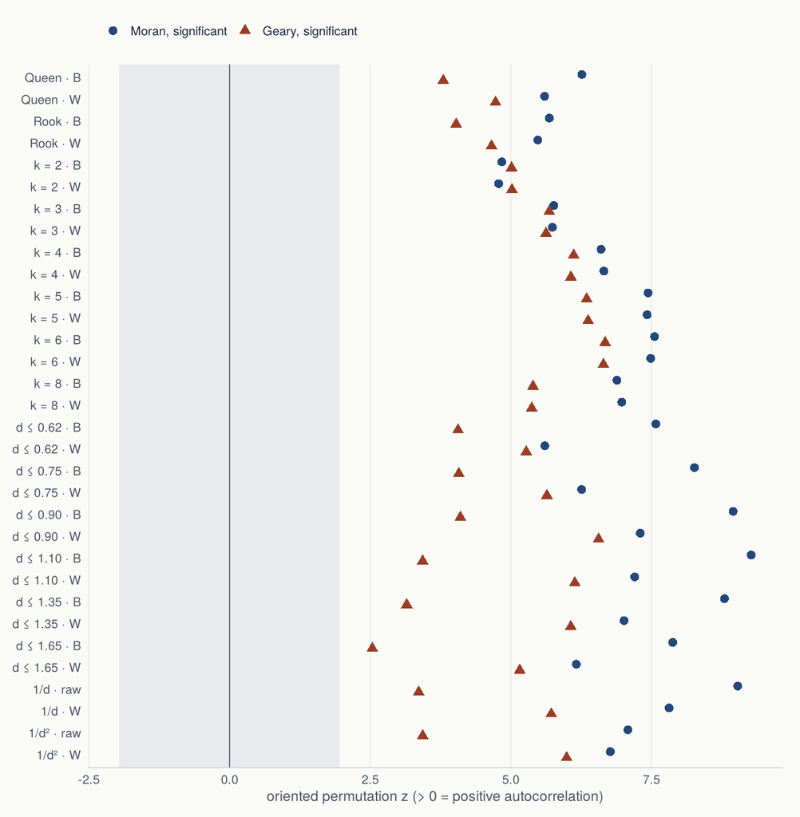

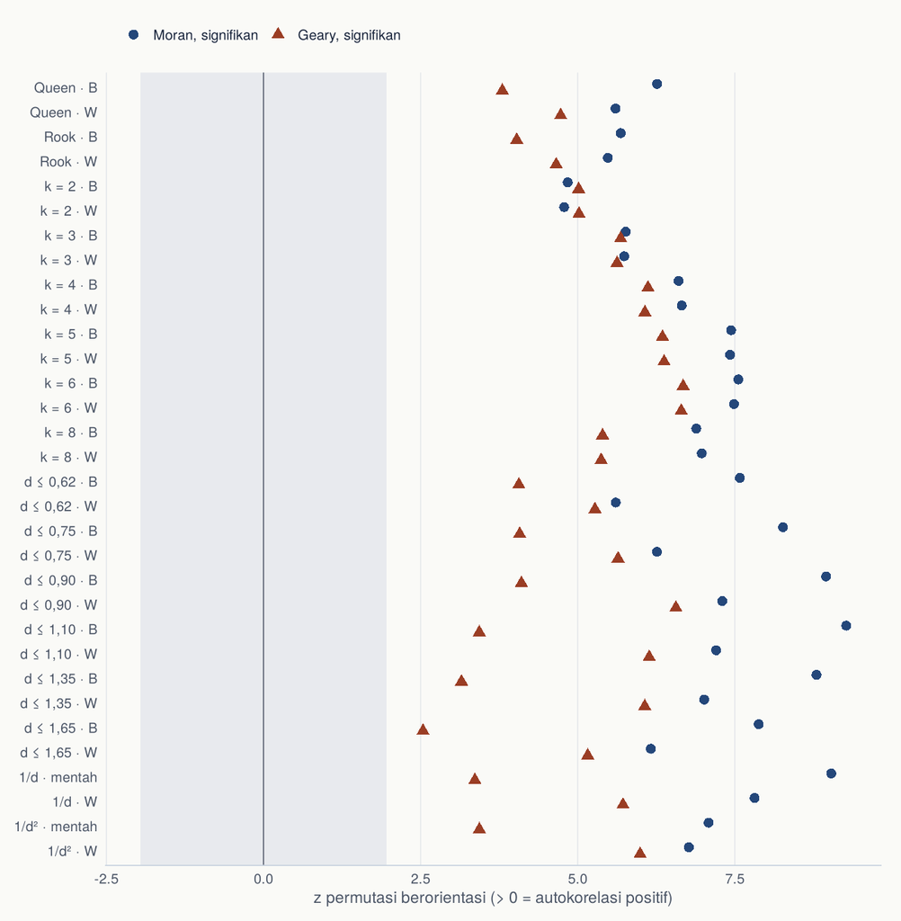

Oriented z for CRIME under every matrix: circles for Moran, triangles for Geary, filled when significant. The shaded band is |z| < 1.96. Moran’s I is significant under 32 of 32 matrices and Geary’s C under 32. None of the 64 tests points to negative autocorrelation. What moves is the strength: z for Moran ranges from 4.78 to 9.27.z berorientasi CRIME pada setiap matriks: lingkaran untuk Moran, segitiga untuk Geary, terisi bila signifikan. Pita abu-abu adalah |z| < 1,96. Moran’s I signifikan pada 32 dari 32 matriks dan Geary’s C pada 32. Tidak satu pun dari 64 uji menunjukkan autokorelasi negatif. Yang bergeser adalah kekuatannya: z Moran berkisar dari 4,78 sampai 9,27.

The direction of the answer is stable: CRIME is positively autocorrelated under every rule that finds anything. The size of the answer is not. Moran’s I runs from 0.153 (1/d · W) to 0.607 (k = 2 · B), a factor of 4.0, and Geary’s C from 0.325 to 0.846. A report that quotes one of these numbers as “the” spatial autocorrelation of crime in Columbus is quoting a choice.

Arah jawabannya stabil: CRIME berautokorelasi positif pada setiap aturan yang menemukan sesuatu. Besar jawabannya tidak stabil. Moran’s I berkisar dari 0,153 (1/d · W) sampai 0,607 (k = 2 · B), selisih 4,0 kali lipat, dan Geary’s C dari 0,325 sampai 0,846. Laporan yang menyebut salah satu angka ini sebagai “nilai” autokorelasi spasial kejahatan di Columbus sebenarnya sedang menyebut sebuah pilihan.

Figure 4Gambar 4Turning one dial at a timeMemutar satu kenop setiap kali

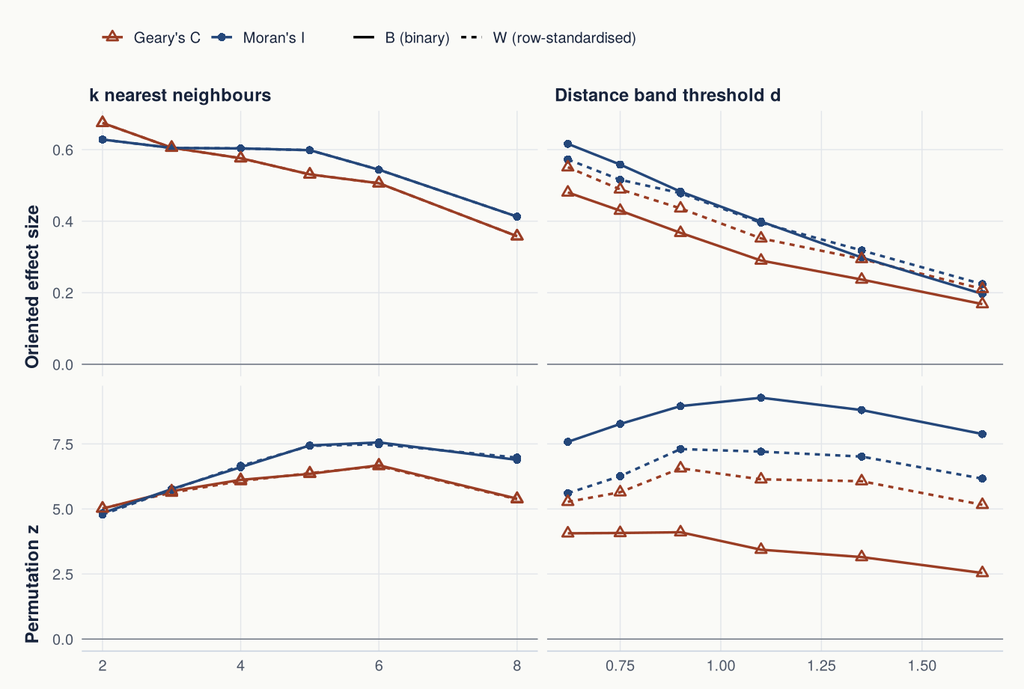

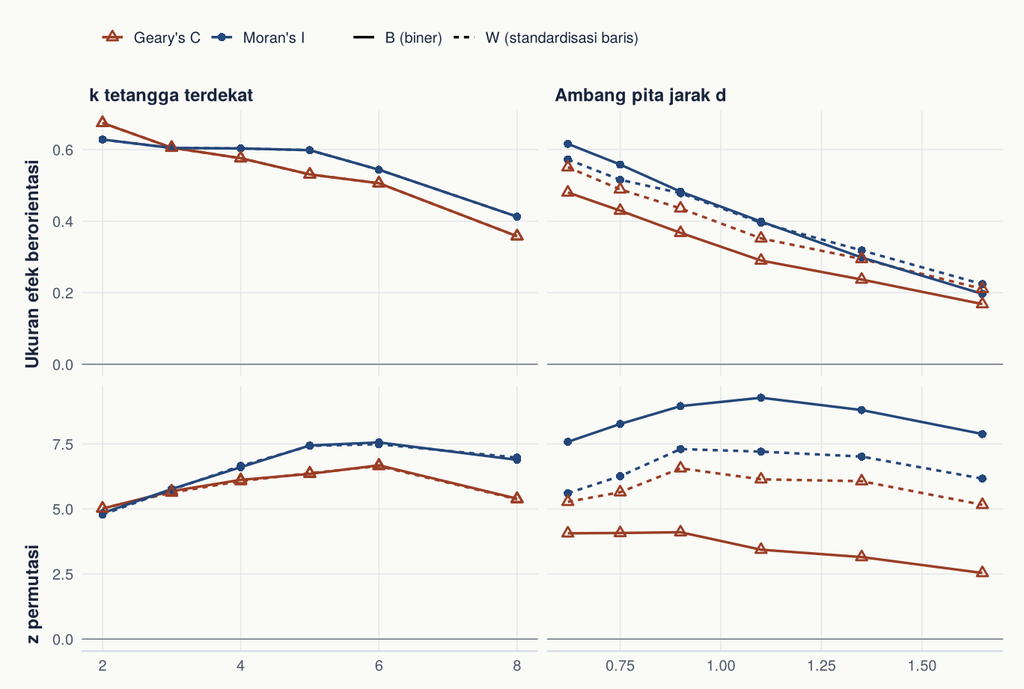

Effect size (I − E(I) for Moran, 1 − C for Geary) and z as the number of neighbours k or the distance threshold d grows. More neighbours average over larger areas: the effect size falls while z can still rise, because the test gains information. For KNN the B and W lines coincide, because every row has exactly k neighbours. Strength and significance answer different questions.Ukuran efek (I − E(I) untuk Moran, 1 − C untuk Geary) dan z ketika jumlah tetangga k atau ambang jarak d bertambah. Makin banyak tetangga berarti rata-rata atas wilayah yang lebih luas: ukuran efek turun, sementara z masih bisa naik karena uji mendapat lebih banyak informasi. Pada KNN garis B dan W berimpit, karena setiap baris punya tepat k tetangga. Kekuatan dan signifikansi menjawab pertanyaan yang berbeda.

### How a search would lookSeperti apa hasil pencarian

If an analyst tried all 32 matrices and reported the best one, this is what they could pick from:

Bila seorang analis mencoba ke-32 matriks lalu melaporkan yang terbaik, inilah pilihan yang tersedia:

Range of CRIME p-values across 32 matrices

| Index | Smallest p | under W | Largest p | under W | % of W significant |
| --- | --- | --- | --- | --- | --- |
| Geary’s C | < 0.001 | Queen · B | 0.016 | d ≤ 1.65 · B | 100 |
| Moran’s I | < 0.001 | Queen · B | < 0.001 | d ≤ 1.35 · W | 100 |

With 9,999 two-sided permutations the smallest possible p is 0.0002.

Rentang p-value CRIME di antara 32 matriks

| Indeks | p terkecil | dengan W | p terbesar | dengan W | % W signifikan |
| --- | --- | --- | --- | --- | --- |
| Geary’s C | < 0,001 | Queen · B | 0,016 | d ≤ 1,65 · B | 100 |
| Moran’s I | < 0,001 | Queen · B | < 0,001 | d ≤ 1,35 · W | 100 |

p terkecil yang mungkin dengan 9.999 permutasi dua sisi adalah 0,0002.

For CRIME the search cannot reverse the verdict for Moran’s I, which is significant under 100% of the matrices. That is the good news, and it is specific to a strong signal. In the same study, three of the other five variables (HOVAL, OPEN, PLUMB) have at least one index whose significance can be switched on or off by the choice of $W$ alone (`output/csv/05d_risiko_specification_searching.csv`).

Untuk CRIME, pencarian seperti ini tidak dapat membalik putusan Moran’s I, yang signifikan pada 100% matriks. Itu kabar baik, dan berlaku khusus untuk sinyal yang kuat. Dalam studi yang sama, tiga dari lima variabel lain (HOVAL, OPEN, PLUMB) punya setidaknya satu indeks yang signifikansinya bisa dinyalakan atau dimatikan hanya dengan memilih $W$ (`output/csv/05d_risiko_specification_searching.csv`).

## Moran versus GearyMoran versus Geary

The two indices reach the same verdict under all 32 matrices: positive autocorrelation, every time. Agreement is expected here because CRIME has no outliers by the 1.5 · IQR rule. Moran weighs products of deviations from the mean, so a large value next to neighbours of the same sign pushes it up. Geary weighs squared jumps between neighbours, so sharp edges pull it. On a variable with a few extreme, clustered values the two can split, as they do for PLUMB in the full study.

Kedua indeks memberi putusan yang sama pada ke-32 matriks: autokorelasi positif, setiap kali. Kesepakatan ini wajar karena CRIME tidak memiliki pencilan menurut aturan 1,5 · IQR. Moran menimbang perkalian simpangan dari rata-rata, sehingga nilai besar yang bertetangga dengan nilai bertanda sama mendorongnya naik. Geary menimbang kuadrat lonjakan antartetangga, sehingga tertarik oleh tepi yang tajam. Pada variabel dengan beberapa nilai ekstrem yang mengelompok, keduanya bisa berbeda, seperti PLUMB dalam studi lengkap.

Figure 5Gambar 5The two verdicts side by sideDua putusan berdampingan

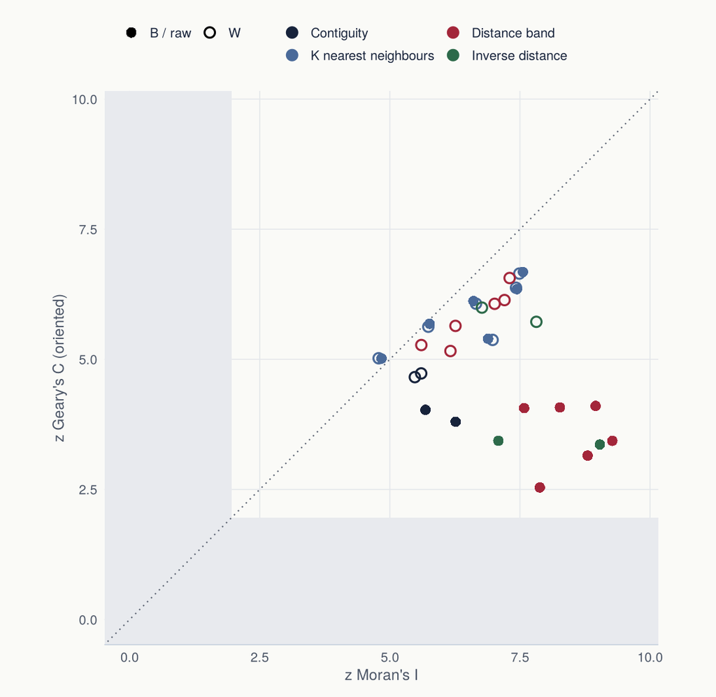

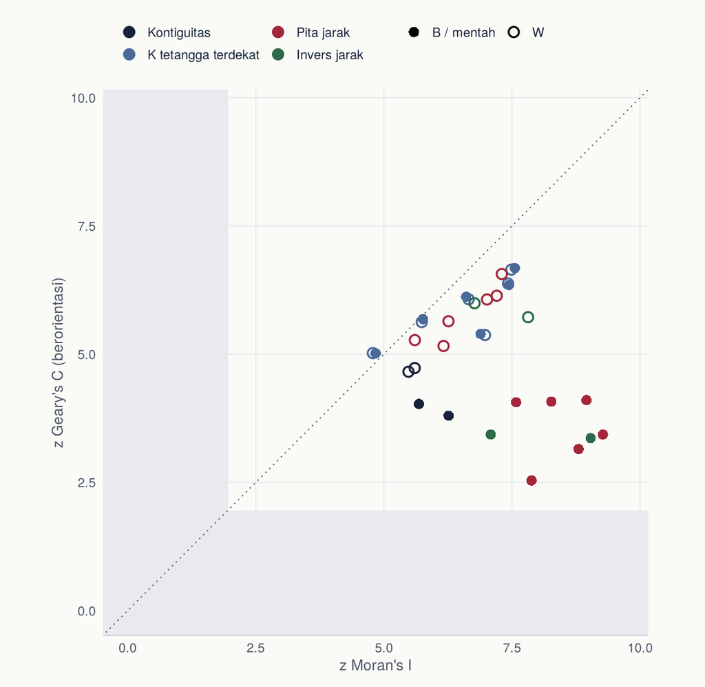

Each point is one matrix: colour gives the family, a filled point binary or raw weights and a hollow point row-standardised. Shaded strips are |z| < 1.96 for either index; the dotted line is equal z. Geary’s z is below Moran’s for 30 of 32 matrices, and the gap is widest for binary distance bands and raw inverse distance, where areas with many neighbours carry most of the weight.Setiap titik adalah satu matriks: warna menunjukkan keluarga, titik penuh bobot biner atau mentah, titik kosong standardisasi baris. Pita abu-abu adalah |z| < 1,96 untuk salah satu indeks; garis titik-titik adalah z yang sama. z Geary lebih kecil daripada z Moran pada 30 dari 32 matriks, dan selisihnya paling lebar pada pita jarak biner dan invers jarak mentah, ketika wilayah dengan banyak tetangga memikul sebagian besar bobot.

## What one neighbourhood can doPengaruh satu lingkungan

A robust pattern should not hinge on one area. Each of the 49 neighbourhoods was removed in turn, $W$ was rebuilt without it, and z was recomputed (jackknife). Under Queen · W, the largest shift in Moran’s z is 1.34 (removing POLYID 7) and in Geary’s z 1.13 (POLYID 7). Across the three matrices tested, no single removal changes the significance of CRIME.

Pola yang robust tidak boleh bergantung pada satu wilayah. Setiap 49 lingkungan dihapus satu per satu, $W$ dibangun ulang tanpa wilayah itu, lalu z dihitung ulang (jackknife). Pada Queen · W, pergeseran terbesar z Moran adalah 1,34 (menghapus POLYID 7) dan z Geary 1,13 (POLYID 7). Pada tiga matriks yang diuji, tidak ada satu penghapusan pun yang mengubah signifikansi CRIME.

Figure 6Gambar 6Leave one neighbourhood outKeluarkan satu lingkungan

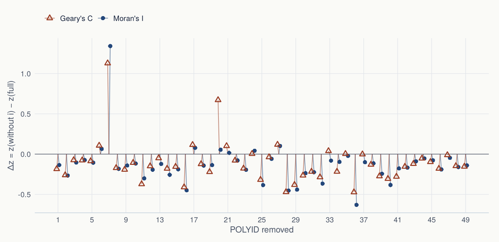

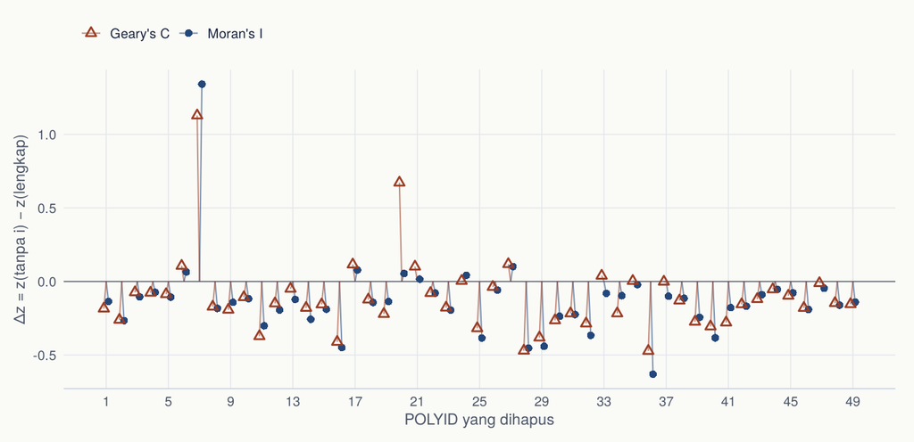

Change in z when each neighbourhood is removed, Queen · W. Shifts of this size do not move CRIME across the 1.96 line, because its z starts far above it (Moran z = 5.60).Perubahan z bila setiap lingkungan dihapus, Queen · W. Pergeseran sebesar ini tidak membuat CRIME melewati garis 1,96, karena z-nya sejak awal jauh di atasnya (z Moran = 5,60).

Replacing CRIME by its ranks (which removes the effect of extreme values) changes z by 0.77 on average for Moran and 1.16 for Geary, and does not change significance under any matrix. Switching between B and W standardisation changes z by 0.87 (Moran) and 1.26 (Geary) on average.

Mengganti CRIME dengan peringkatnya (yang menghilangkan pengaruh nilai ekstrem) mengubah z rata-rata sebesar 0,77 untuk Moran dan 1,16 untuk Geary, dan tidak mengubah signifikansi pada matriks mana pun. Beralih antara standardisasi B dan W mengubah z rata-rata sebesar 0,87 (Moran) dan 1,26 (Geary).

## Local clusters and outliers: where the critique bitesKlaster dan pencilan lokal: di sini kritiknya paling terasa

LISA splits Moran’s I into one value per area and labels each significant area High-High (a high value among high neighbours), Low-Low, High-Low or Low-High. High-High and Low-Low areas are clusters; High-Low and Low-High areas are spatial outliers, values unlike their neighbours, and are not part of a cluster. Each area gets its own conditional permutation test, so 49 tests are run at once; at α = 0.05 about 2.5 areas would look significant by chance alone. The p-values are therefore corrected with the Benjamini–Hochberg false discovery rate (FDR).

Under Queen · W, 15 neighbourhoods have a raw p below 0.05 and 4 remain after FDR: POLYID 16, POLYID 24, POLYID 25 and POLYID 29.

LISA memecah Moran’s I menjadi satu nilai per wilayah dan memberi label pada setiap wilayah signifikan: High-High (nilai tinggi di antara tetangga bernilai tinggi), Low-Low, High-Low, atau Low-High. Wilayah High-High dan Low-Low adalah klaster; wilayah High-Low dan Low-High adalah pencilan spasial, yaitu nilai yang berbeda dari tetangganya, dan bukan bagian dari klaster. Setiap wilayah diuji dengan permutasi bersyaratnya sendiri, sehingga 49 uji dijalankan sekaligus; pada α = 0,05 sekitar 2,5 wilayah akan tampak signifikan hanya karena kebetulan. Karena itu p-value dikoreksi dengan *false discovery rate* (FDR) Benjamini–Hochberg.

Pada Queen · W, 15 lingkungan memiliki p mentah di bawah 0,05 dan 4 tetap signifikan setelah FDR: POLYID 16, POLYID 24, POLYID 25 dan POLYID 29.

Figure 7Gambar 7Three local statistics, one reference matrixTiga statistik lokal, satu matriks acuan

#### LISA

Local Moran, Queen · W, FDR 5%

[figure not shown]

**LISA class**High-High (4)Low-Low (0)High-Low (0)Low-High (0)Not significant (45)

#### Getis–Ord G<sub>i</sub>*

Binary Queen including self, FDR 5%

[figure not shown]

**Gi* class**Hot spot (4)Cold spot (0)Not significant (45)

#### Local Geary

Queen · W, FDR 5%

[figure not shown]

**Local Geary class**High-High (4)Low-Low (1)Other positive (0)Negative (0)Not significant (44)

#### LISA

Moran lokal, Queen · W, FDR 5%

[figure not shown]

**Kelas LISA**Tinggi-Tinggi (4)Rendah-Rendah (0)Tinggi-Rendah (0)Rendah-Tinggi (0)Tidak signifikan (45)

#### Getis–Ord G<sub>i</sub>*

Queen biner dengan diri sendiri, FDR 5%

[figure not shown]

**Kelas Gi***Hot spot (4)Cold spot (0)Tidak signifikan (45)

#### Local Geary

Queen · W, FDR 5%

[figure not shown]

**Kelas Local Geary**Tinggi-Tinggi (4)Rendah-Rendah (1)Positif lain (0)Negatif (0)Tidak signifikan (44)

Gi* marks 4 hot spots (16, 24, 25 and 29) and 0 cold spots; Local Geary flags 5 areas. Red always means high values among high neighbours and blue low among low, but each legend counts its own method’s classes. Local Geary’s “other positive” (similar values that are neither clearly high nor clearly low) and “negative” (a value unlike its neighbours) are kept apart. The three tools point at the same part of the city. Hover for values.Gi* menandai 4 hot spot (16, 24, 25 dan 29) dan 0 cold spot; Local Geary menandai 5 wilayah. Merah selalu berarti nilai tinggi di antara tetangga tinggi dan biru nilai rendah di antara tetangga rendah, tetapi setiap legenda menghitung kelas metodenya sendiri. Kelas “positif lain” pada Local Geary (nilai mirip yang tidak jelas tinggi atau rendah) dan “negatif” (nilai yang berbeda dari tetangganya) dipisahkan. Ketiga alat menunjuk bagian kota yang sama. Arahkan kursor untuk melihat nilainya.

That map is the one most reports would print. The next figure prints the same statistic, on the same data, under six other matrices.

Peta itulah yang biasanya dicetak dalam laporan. Gambar berikut mencetak statistik yang sama, pada data yang sama, dengan enam matriks lain.

Figure 8Gambar 8Same statistic, six other mapsStatistik sama, enam peta lain

#### d ≤ 1.65 · B

30 significant (FDR), 32 by raw p

[figure not shown]

#### 1/d · W

21 significant (FDR), 21 by raw p

[figure not shown]

#### d ≤ 1.10 · W

21 significant (FDR), 28 by raw p

[figure not shown]

#### k = 8 · W

13 significant (FDR), 16 by raw p

[figure not shown]

#### k = 4 · W

0 significant (FDR), 21 by raw p

[figure not shown]

#### k = 2 · W

0 significant (FDR), 2 by raw p

[figure not shown]

**LISA class, FDR 5%**High-HighLow-LowHigh-LowLow-HighNot significant

#### d ≤ 1,65 · B

30 signifikan (FDR), 32 dengan p mentah

[figure not shown]

#### 1/d · W

21 signifikan (FDR), 21 dengan p mentah

[figure not shown]

#### d ≤ 1,10 · W

21 signifikan (FDR), 28 dengan p mentah

[figure not shown]

#### k = 8 · W

13 signifikan (FDR), 16 dengan p mentah

[figure not shown]

#### k = 4 · W

0 signifikan (FDR), 21 dengan p mentah

[figure not shown]

#### k = 2 · W

0 signifikan (FDR), 2 dengan p mentah

[figure not shown]

**Kelas LISA, FDR 5%**Tinggi-TinggiRendah-RendahTinggi-RendahRendah-TinggiTidak signifikan

LISA for CRIME, FDR 5%, under six alternative matrices, drawn at the same scale and extent as the reference map. Across all 32, the number of significant neighbourhoods ranges from 0 to 30, and 6 matrices find none. Moran’s global test is significant under 32 of those same 32 matrices: a significant global index does not guarantee a single significant local cluster.LISA untuk CRIME, FDR 5%, dengan enam matriks alternatif, digambar dengan skala dan cakupan yang sama dengan peta acuan. Di antara ke-32 matriks, jumlah lingkungan signifikan berkisar dari 0 sampai 30, dan 6 matriks tidak menemukan satu pun. Uji global Moran signifikan pada 32 dari 32 matriks yang sama: indeks global yang signifikan tidak menjamin ada satu pun klaster lokal yang signifikan.

Figure 9Gambar 9How strong, and how stableSeberapa kuat, dan seberapa stabil

#### Significance

Queen · W, FDR

[figure not shown]

**LISA p after FDR**p ≤ 0.001 (0)p ≤ 0.01 (0)p ≤ 0.05 (4)Not significant (45)

#### Stability

Significant (FDR 5%) under how many of 32 matrices

[figure not shown]

**Number of matrices**Never (12)1–8 matrices (19)9–16 matrices (7)17–31 matrices (11)All 32 (0)

#### Signifikansi

Queen · W, FDR

[figure not shown]

**p LISA setelah FDR**p ≤ 0,001 (0)p ≤ 0,01 (0)p ≤ 0,05 (4)Tidak signifikan (45)

#### Stabilitas

Signifikan (FDR 5%) pada berapa dari 32 matriks

[figure not shown]

**Jumlah matriks**Tidak pernah (12)1–8 matriks (19)9–16 matriks (7)17–31 matriks (11)Semua 32 (0)

Left: the FDR-corrected p of each neighbourhood under Queen · W; the smallest p is the darkest. Right: the number of matrices under which the neighbourhood is significant. 37 neighbourhoods are significant under at least one matrix, 0 under all 32.Kiri: p terkoreksi FDR setiap lingkungan pada Queen · W; p terkecil paling gelap. Kanan: jumlah matriks yang membuat lingkungan itu signifikan. 37 lingkungan signifikan pada setidaknya satu matriks, 0 pada ke-32 matriks.

Figure 10Gambar 10Every neighbourhood under every matrixSetiap lingkungan pada setiap matriks

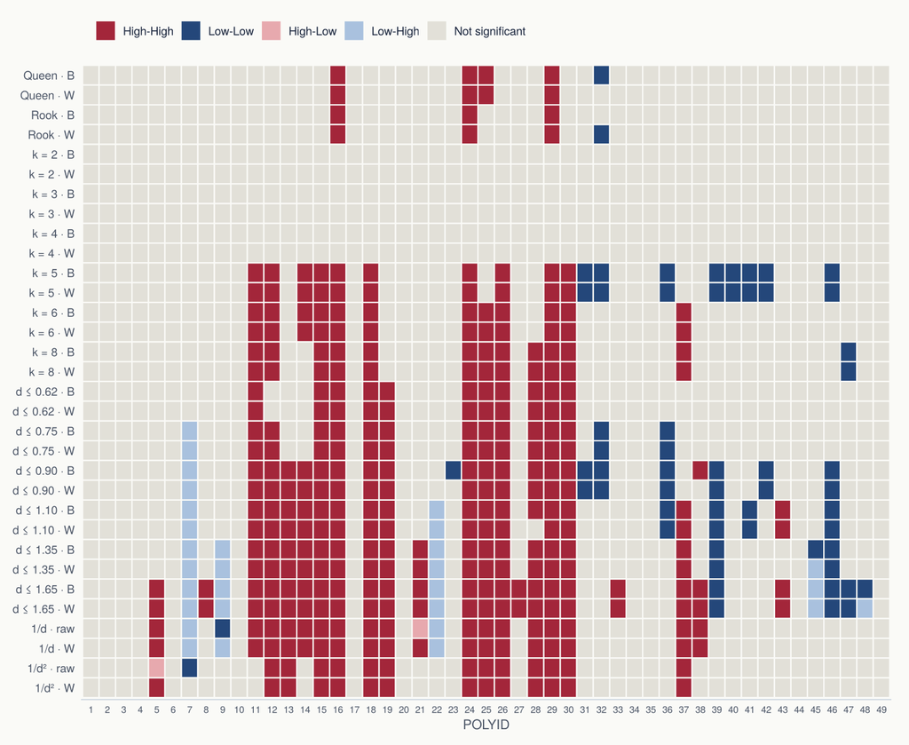

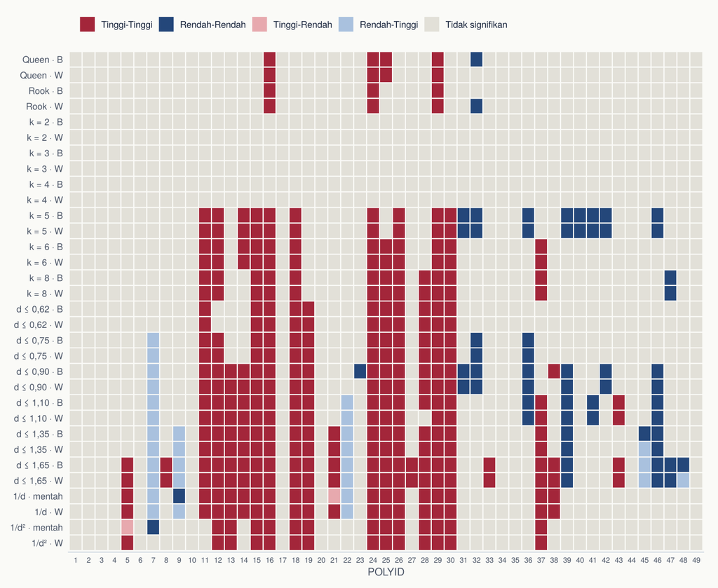

One row per matrix, one column per neighbourhood, FDR 5%. 37 neighbourhoods are flagged by at least one matrix and 0 by all 32. Under the least similar matrix (d ≤ 1.65 · B) only 47% of the 49 labels match Queen · W.Satu baris per matriks, satu kolom per lingkungan, FDR 5%. 37 lingkungan ditandai oleh setidaknya satu matriks dan 0 oleh ke-32 matriks. Pada matriks yang paling berbeda (d ≤ 1,65 · B) hanya 47% dari 49 label yang sama dengan Queen · W.

The global sign of CRIME never changes, yet the local map ranges from empty to 30 flagged neighbourhoods. LISA results are the part of this analysis most exposed to the choice of $W$, and the part most often shown as a single map. A LISA cluster is evidence only when it appears under a range of defensible matrices and survives the FDR correction.

Tanda global CRIME tidak pernah berubah, tetapi peta lokalnya berkisar dari kosong sampai 30 lingkungan yang ditandai. Hasil LISA adalah bagian analisis yang paling rentan terhadap pilihan $W$, sekaligus bagian yang paling sering ditampilkan sebagai satu peta saja. Klaster LISA baru menjadi bukti bila muncul pada berbagai matriks yang dapat dipertanggungjawabkan dan tetap signifikan setelah koreksi FDR.

## Which matrix to trust: a simulationMatriks mana yang dipercaya: simulasi

The chapters so far show that $W$ matters on the observed data, but there the true pattern is unknown, so they cannot say which $W$ is right. This chapter answers the revision questions: which matrices are robust and which are sensitive, which one to use when nothing is known, whether results depend on the diagonal or on placement, and whether the computation itself is correct. Everything is done for CRIME only.

Bab-bab sebelumnya menunjukkan bahwa $W$ berpengaruh pada data teramati, tetapi di sana pola sebenarnya tidak diketahui, sehingga tidak bisa dikatakan $W$ mana yang benar. Bab ini menjawab pertanyaan revisi: matriks mana yang robust dan mana yang sensitif, matriks mana yang dipakai bila tidak ada informasi, apakah hasil bergantung pada diagonal atau pada letak bobot, dan apakah komputasinya sendiri benar. Semuanya dilakukan hanya untuk CRIME.

### Diagonal or placement? Computational testsDiagonal atau letak? Uji komputasi

Computational tests U1–U7 for CRIME

| Test | Result | Conclusion |
| --- | --- | --- |
| U1 Own implementation = spdep (32 W) | max \|diff\| = 2.2e-16 | Computation correct |
| U2 Relabel areas in x and W together (200 times × 32 W) | max \|diff\| = 2.2e-16 | Labels do not matter |
| U3 Rewire Queen neighbours at random, same counts (999 times) | I: 0.515 → mean −0.025 (SD 0.064) | Placement decides the result |
| U4a Diagonal wᵢᵢ = 1 on Queen: Moran’s I | 0.515 → 0.599 (formula: 0.599) | Diagonal inflates I |
| U4b Diagonal wᵢᵢ = 1 on Queen: Geary’s C | 0.592 → 0.490 (= C · S₀/S₀′ = 0.490) | Only through S₀ |
| U5 Symmetrise (W + Wᵀ)/2 (32 W) | max \|diff\| = 1.1e-16 | Only the symmetric part is used |
| U6 Rescale 7.3 · W (32 W) | max \|diff\| = 2.2e-16 | Scale does not matter |
| U7 Analytic SD vs SD of 9,999 permutations (32 W) | max \|ratio − 1\| = 0.012 | Analytic moments are valid |

Uji komputasi U1–U7 untuk CRIME

| Uji | Hasil | Kesimpulan |
| --- | --- | --- |
| U1 Implementasi sendiri = spdep (32 W) | maks \|selisih\| = 2.2e-16 | Hitungan benar |
| U2 Ubah label wilayah pada x dan W bersamaan (200 kali × 32 W) | maks \|selisih\| = 2.2e-16 | Label tidak berpengaruh |
| U3 Acak letak tetangga Queen, jumlah tetangga tetap (999 kali) | I: 0,515 → rata-rata −0,025 (SD 0,064) | Letak menentukan hasil |
| U4a Diagonal wᵢᵢ = 1 pada Queen: Moran’s I | 0,515 → 0,599 (rumus: 0,599) | Diagonal menggelembungkan I |
| U4b Diagonal wᵢᵢ = 1 pada Queen: Geary’s C | 0,592 → 0,490 (= C · S₀/S₀′ = 0,490) | Hanya lewat S₀ |
| U5 Simetrisasi (W + Wᵀ)/2 (32 W) | maks \|selisih\| = 1.1e-16 | Hanya bagian simetris yang dipakai |
| U6 Skala 7,3 · W (32 W) | maks \|selisih\| = 2.2e-16 | Skala tidak berpengaruh |
| U7 SD analitik vs SD 9.999 permutasi (32 W) | maks \|rasio − 1\| = 0,012 | Momen analitik sah dipakai |

Figure 11Gambar 11Placement, not labels, makes the patternLetak, bukan label, yang membentuk pola

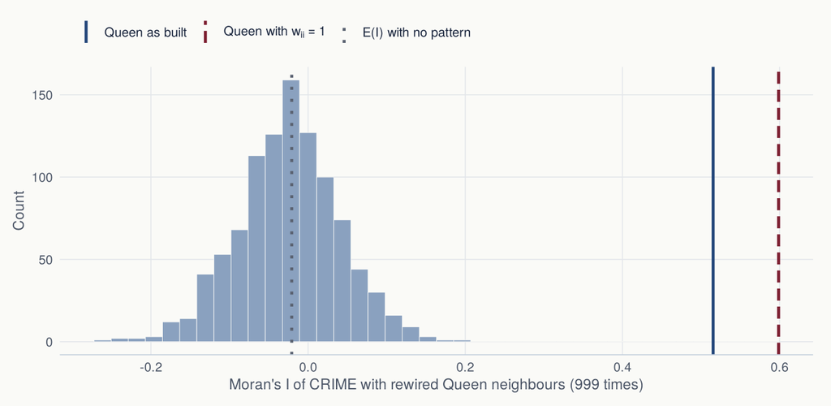

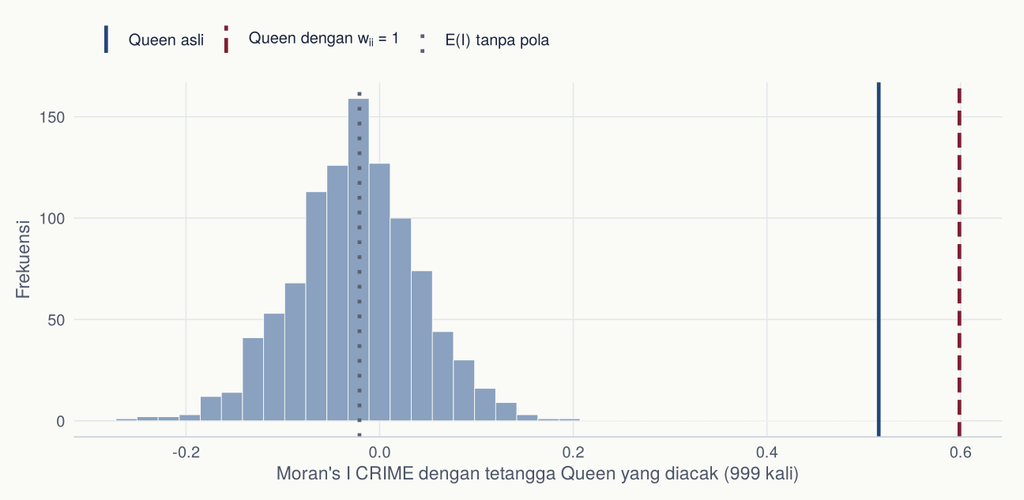

Keep every neighbourhood’s number of Queen neighbours, but choose who they are at random: Moran’s I falls from 0.515 to an average of −0.025, close to E(I) = −0.021. Setting the diagonal to 1 does the opposite and inflates I to 0.599, because every area becomes its own perfectly similar neighbour. Geary’s numerator ignores the diagonal (xᵢ − xᵢ = 0), so C only changes through S₀.Jumlah tetangga Queen setiap lingkungan dipertahankan, tetapi siapa tetangganya dipilih acak: Moran’s I turun dari 0,515 menjadi rata-rata −0,025, mendekati E(I) = −0,021. Mengisi diagonal dengan 1 berefek sebaliknya dan menggelembungkan I menjadi 0,599, karena setiap wilayah menjadi tetangga dirinya sendiri yang sempurna mirip. Pembilang Geary mengabaikan diagonal (xᵢ − xᵢ = 0), sehingga C hanya berubah lewat S₀.

**Answer to the diagonal question.** The result depends on where the weights are placed (which pairs are linked), not on how the areas are numbered, how the matrix is scaled, or whether it is symmetric. The diagonal must be zero: a non-zero $w_{ii}$ adds $z_i^2 \ge 0$ to Moran’s numerator and manufactures positive autocorrelation.

**Jawaban atas pertanyaan diagonal.** Hasil bergantung pada letak bobot (pasangan mana yang dihubungkan), bukan pada penomoran wilayah, skala matriks, atau simetrinya. Diagonal wajib nol: $w_{ii}$ yang tidak nol menambahkan $z_i^2 \ge 0$ ke pembilang Moran dan menciptakan autokorelasi positif yang semu.

### DesignDesain

Simulated maps are made from the **real CRIME values**, rearranged according to a pattern we choose. For each replicate: (1) generate a latent surface $y$ from one of five processes, (2) give the largest CRIME value to the area with the largest $y$, the second largest to the second, and so on, (3) test Moran’s I and Geary’s C under all 32 matrices at α = 0.05. The distribution of values is always exactly that of CRIME; only their arrangement changes. Five processes are used so that no matrix wins just because it matches the process:

Peta simulasi dibuat dari **nilai CRIME yang asli**, yang disusun ulang mengikuti pola yang kita tentukan. Untuk setiap ulangan: (1) bangkitkan permukaan laten $y$ dari salah satu dari lima proses, (2) berikan nilai CRIME terbesar ke wilayah dengan $y$ terbesar, terbesar kedua ke wilayah kedua, dan seterusnya, (3) uji Moran’s I dan Geary’s C dengan ke-32 matriks pada α = 0,05. Sebaran nilainya selalu sama persis dengan CRIME; hanya susunannya yang berubah. Lima proses dipakai agar tidak ada matriks yang menang hanya karena kebetulan cocok dengan prosesnya:

Five generating processes

| Code | Generating process | Shape of the pattern |
| --- | --- | --- |
| G1 | SAR on Queen · W | Clusters among touching areas |
| G2 | SAR on k = 4 · W | Clusters among nearest neighbours |
| G3 | SAR on band d ≤ 1.10 · W | Clusters within a fixed radius |
| G4 | Geostatistical, covariance e^(−d) | Similarity decays smoothly with distance |
| G5 | Radial trend from DISCBD | Gradient from downtown to the edge |

SAR: y = (I − ρW)⁻¹ε. The strength of each process is calibrated so that the best matrix has power 0.30, 0.50, 0.70, 0.90. 5,000 replicates without a pattern and 1,000 per scenario.

Lima proses pembangkit

| Kode | Proses pembangkit | Bentuk pola |
| --- | --- | --- |
| G1 | SAR dengan Queen · W | Klaster antarwilayah yang bersentuhan |
| G2 | SAR dengan k = 4 · W | Klaster antartetangga terdekat |
| G3 | SAR dengan pita d ≤ 1,10 · W | Klaster dalam radius tetap |
| G4 | Geostatistik, kovarians e^(−d) | Kemiripan meluruh mulus dengan jarak |
| G5 | Tren radial dari DISCBD | Gradien dari pusat kota ke pinggiran |

SAR: y = (I − ρW)⁻¹ε. Kekuatan setiap proses dikalibrasi agar daya matriks terbaik bernilai 0,30; 0,50; 0,70; 0,90. 5.000 ulangan tanpa pola dan 1.000 ulangan per skenario.

The strength of each process is calibrated rather than fixed, because the same $\rho$ means very different pattern strength in different processes. Calibration sets the power of the best matrix to 0.30, 0.50, 0.70 and 0.90, so every scenario is equally hard for the best choice and the comparison is fair.

Kekuatan setiap proses dikalibrasi, bukan ditetapkan, karena $\rho$ yang sama menghasilkan kekuatan pola yang sangat berbeda pada proses yang berbeda. Kalibrasi membuat daya matriks terbaik bernilai 0,30; 0,50; 0,70; dan 0,90, sehingga setiap skenario sama sulitnya bagi pilihan terbaik dan perbandingannya adil.

### Criteria, fixed before the runKriteria, ditetapkan sebelum simulasi

Simulation criteria

| Criterion | Definition | Threshold |
| --- | --- | --- |
| K1 Test size | Share of H₀ rejected when there is no pattern | Acceptable if 0.025–0.075 (Bradley, 1978) |
| K2 Mean power | Share of patterns detected, averaged over 5 processes × 4 strengths | Higher is better |
| K3 Maximum regret | Power of the best matrix minus power of this one, worst of 20 scenarios | Smaller is more robust |
| K4 Worst-case power | Lowest power across the 5 processes at strength 0.50 | Higher is better |
| K5 Moran–Geary agreement | Share of replicates where both indices reach the same decision | Supporting |

Kriteria simulasi

| Kriteria | Definisi | Batas |
| --- | --- | --- |
| K1 Ukuran uji | Proporsi H₀ ditolak ketika tidak ada pola | Wajar bila 0,025–0,075 (Bradley, 1978) |
| K2 Daya rata-rata | Proporsi pola terdeteksi, rata-rata atas 5 proses × 4 tingkat kekuatan | Makin tinggi makin baik |
| K3 Penyesalan maksimum | Daya matriks terbaik dikurangi daya matriks ini, diambil yang terburuk dari 20 skenario | Makin kecil makin robust |
| K4 Daya terburuk | Daya terendah di antara 5 proses pada tingkat 0,50 | Makin tinggi makin baik |
| K5 Kesepakatan Moran–Geary | Proporsi ulangan dengan keputusan kedua indeks sama | Pelengkap |

**Classification** (on Moran’s I; Geary is classified the same way, separately): **robust** if K1 is acceptable and the maximum regret is at most 0.15, **sensitive** if K1 fails or the maximum regret exceeds 0.30, **intermediate** otherwise. **Recommendation without information**: the matrix with the smallest maximum regret among those with acceptable size (minimax regret). It guarantees the smallest worst-case loss whatever the true process is. The thresholds 0.15 and 0.30 are conventions, so the recommendation is re-checked under other rules below.

**Klasifikasi** (pada Moran’s I; Geary diklasifikasi dengan cara yang sama secara terpisah): **robust** bila K1 wajar dan penyesalan maksimum paling besar 0,15, **sensitif** bila K1 tidak wajar atau penyesalan maksimum lebih dari 0,30, **menengah** di antaranya. **Rekomendasi tanpa informasi**: matriks dengan penyesalan maksimum terkecil di antara matriks yang ukuran ujinya wajar (*minimax regret*). Aturan ini menjamin kerugian terburuk paling kecil, apa pun proses yang sebenarnya. Batas 0,15 dan 0,30 adalah konvensi, sehingga rekomendasi diperiksa ulang dengan aturan lain di bawah.

### Checking the simulation itselfMemeriksa simulasinya sendiri

Computational checks on the simulation engine

| Check | Result |
| --- | --- |
| Distribution of simulated values = distribution of CRIME (25,000 data sets) | Pass |
| Mean Moran’s I rises monotonically with pattern strength in all five processes | Pass |
| Identical results when rerun with the same seed | Pass |
| Monte Carlo error of the size estimate at 5,000 null replicates (SE) | 0.0031 |
| Analytic test decision = 999-permutation test decision (median, 4 W × 300 replicates) | 98.0% |

Uji komputasi atas mesin simulasi

| Pemeriksaan | Hasil |
| --- | --- |
| Sebaran nilai data simulasi = sebaran CRIME asli (25.000 kumpulan data) | Lulus |
| Rata-rata Moran’s I naik monoton terhadap kekuatan pola pada kelima proses | Lulus |
| Hasil identik bila dijalankan ulang dengan seed yang sama | Lulus |
| Galat Monte Carlo ukuran uji pada 5.000 ulangan nol (SE) | 0,0031 |
| Keputusan uji analitik = uji permutasi 999 kali (median, 4 W × 300 ulangan) | 98,0% |

### ResultsHasil

Figure 12Gambar 12K1: false alarms when there is nothing to findK1: alarm palsu saat tidak ada yang dicari

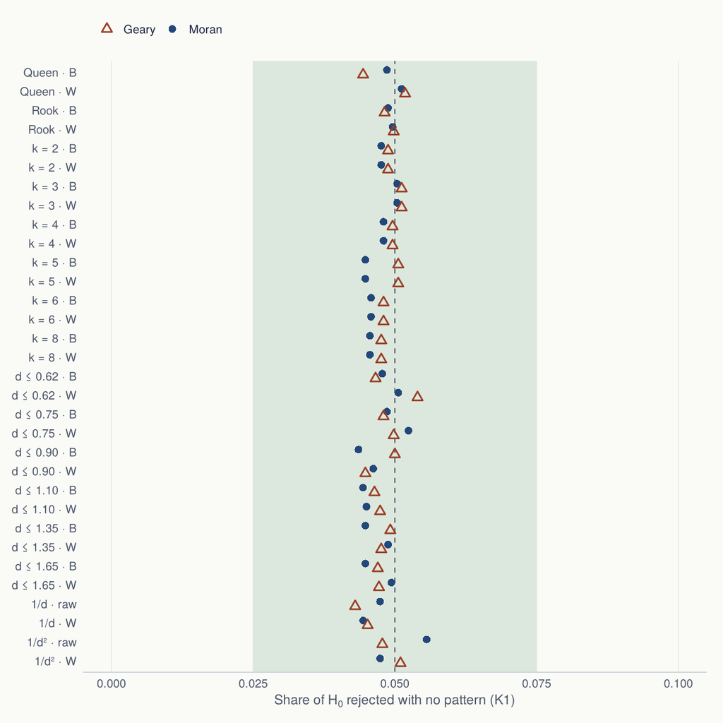

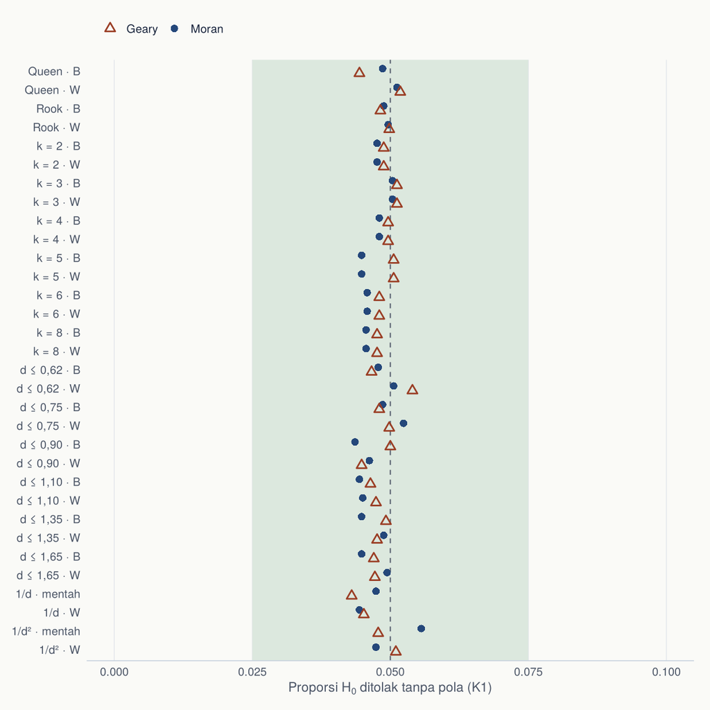

Test size from 5,000 replicates with no spatial pattern. The green band is Bradley’s acceptable range. All 32 matrices pass K1 for both Moran’s I and Geary’s C.Ukuran uji dari 5.000 ulangan tanpa pola spasial. Pita hijau adalah rentang wajar Bradley. Ke-32 matriks lolos K1 untuk Moran’s I maupun Geary’s C.

Figure 13Gambar 13K3: how much power each matrix can loseK3: seberapa banyak daya yang bisa hilang

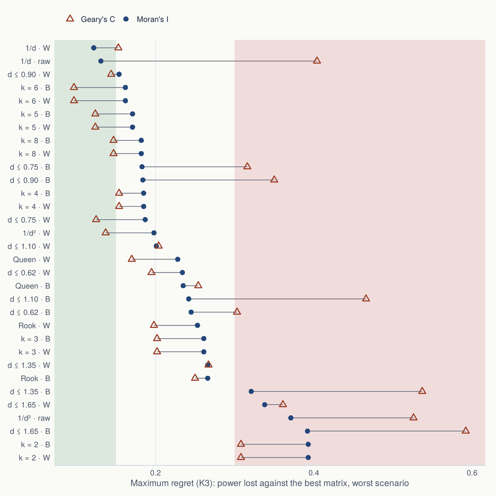

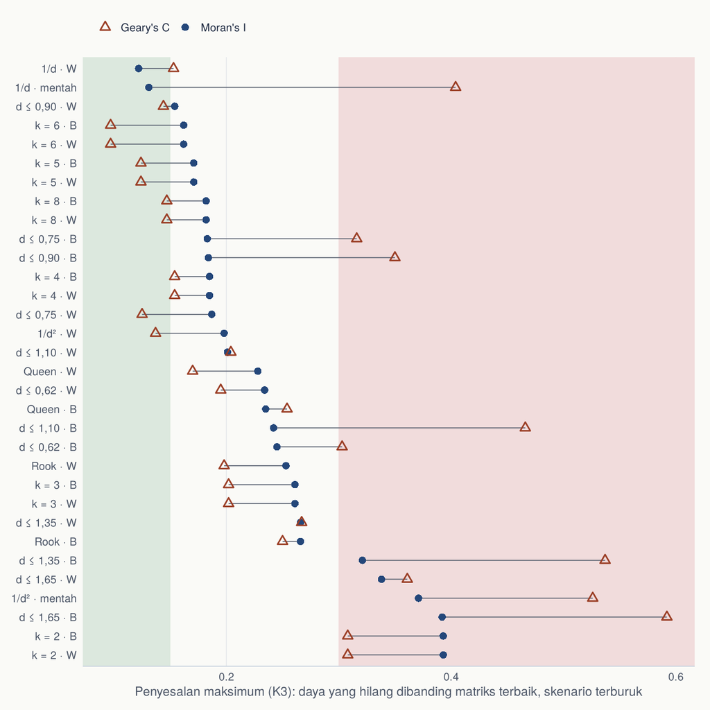

Rows ordered from the most robust (top) for Moran’s I. Green: regret ≤ 0.15 (robust). Red: regret > 0.30 (sensitive). The worst matrix, k = 2 · B, can lose 0.393 of power; the best, 1/d · W, at most 0.122.Baris diurutkan dari yang paling robust (atas) untuk Moran’s I. Hijau: penyesalan ≤ 0,15 (robust). Merah: penyesalan > 0,30 (sensitif). Matriks terburuk, k = 2 · B, bisa kehilangan daya 0,393; yang terbaik, 1/d · W, paling banyak 0,122.

Classification of the 32 matrices for CRIME (ordered by Moran K3)

| # | Matrix | K1 size | K2 mean power | K3 max regret | K4 worst power | K3 Geary | K5 agreement | Moran class | Geary class |
| --- | --- | --- | --- | --- | --- | --- | --- | --- | --- |
| 1 | 1/d · W | 0.044 | 0.538 | 0.122 | 0.392 | 0.153 | 0.892 | Robust | Intermediate |
| 2 | 1/d · raw | 0.047 | 0.517 | 0.131 | 0.388 | 0.404 | 0.729 | Robust | Sensitive |
| 3 | d ≤ 0.90 · W | 0.046 | 0.530 | 0.154 | 0.372 | 0.144 | 0.955 | Intermediate | Robust |
| 4 | k = 6 · B | 0.046 | 0.523 | 0.162 | 0.355 | 0.097 | 0.944 | Intermediate | Robust |
| 5 | k = 6 · W | 0.046 | 0.523 | 0.162 | 0.355 | 0.097 | 0.944 | Intermediate | Robust |
| 6 | k = 5 · B | 0.045 | 0.525 | 0.171 | 0.351 | 0.124 | 0.940 | Intermediate | Robust |
| 7 | k = 5 · W | 0.045 | 0.525 | 0.171 | 0.351 | 0.124 | 0.940 | Intermediate | Robust |
| 8 | k = 8 · B | 0.046 | 0.514 | 0.182 | 0.349 | 0.147 | 0.920 | Intermediate | Robust |
| 9 | k = 8 · W | 0.046 | 0.514 | 0.182 | 0.349 | 0.147 | 0.920 | Intermediate | Robust |
| 10 | d ≤ 0.75 · B | 0.049 | 0.490 | 0.183 | 0.346 | 0.316 | 0.804 | Intermediate | Sensitive |
| 11 | d ≤ 0.90 · B | 0.044 | 0.508 | 0.184 | 0.342 | 0.350 | 0.800 | Intermediate | Sensitive |
| 12 | k = 4 · B | 0.048 | 0.517 | 0.185 | 0.325 | 0.154 | 0.940 | Intermediate | Intermediate |
| 13 | k = 4 · W | 0.048 | 0.517 | 0.185 | 0.325 | 0.154 | 0.940 | Intermediate | Intermediate |
| 14 | d ≤ 0.75 · W | 0.052 | 0.502 | 0.187 | 0.357 | 0.125 | 0.947 | Intermediate | Robust |
| 15 | 1/d² · W | 0.047 | 0.507 | 0.198 | 0.331 | 0.137 | 0.930 | Intermediate | Robust |
| 16 | d ≤ 1.10 · W | 0.045 | 0.512 | 0.201 | 0.352 | 0.204 | 0.942 | Intermediate | Intermediate |
| 17 | Queen · W | 0.051 | 0.506 | 0.228 | 0.306 | 0.170 | 0.935 | Intermediate | Intermediate |
| 18 | d ≤ 0.62 · W | 0.051 | 0.470 | 0.234 | 0.293 | 0.195 | 0.936 | Intermediate | Intermediate |
| 19 | Queen · B | 0.049 | 0.483 | 0.235 | 0.283 | 0.254 | 0.860 | Intermediate | Intermediate |
| 20 | d ≤ 1.10 · B | 0.044 | 0.499 | 0.242 | 0.320 | 0.466 | 0.766 | Intermediate | Sensitive |
| 21 | d ≤ 0.62 · B | 0.048 | 0.466 | 0.245 | 0.311 | 0.303 | 0.817 | Intermediate | Sensitive |
| 22 | Rook · W | 0.050 | 0.490 | 0.253 | 0.272 | 0.198 | 0.930 | Intermediate | Intermediate |
| 23 | k = 3 · B | 0.050 | 0.481 | 0.261 | 0.261 | 0.202 | 0.935 | Intermediate | Intermediate |
| 24 | k = 3 · W | 0.050 | 0.481 | 0.261 | 0.261 | 0.202 | 0.935 | Intermediate | Intermediate |
| 25 | d ≤ 1.35 · W | 0.049 | 0.476 | 0.266 | 0.312 | 0.267 | 0.938 | Intermediate | Intermediate |
| 26 | Rook · B | 0.049 | 0.469 | 0.266 | 0.255 | 0.250 | 0.883 | Intermediate | Intermediate |
| 27 | d ≤ 1.35 · B | 0.045 | 0.473 | 0.321 | 0.279 | 0.537 | 0.753 | Sensitive | Sensitive |
| 28 | d ≤ 1.65 · W | 0.049 | 0.425 | 0.338 | 0.288 | 0.361 | 0.923 | Sensitive | Sensitive |
| 29 | 1/d² · raw | 0.056 | 0.366 | 0.371 | 0.211 | 0.526 | 0.775 | Sensitive | Sensitive |
| 30 | d ≤ 1.65 · B | 0.045 | 0.433 | 0.392 | 0.235 | 0.592 | 0.735 | Sensitive | Sensitive |
| 31 | k = 2 · B | 0.048 | 0.411 | 0.393 | 0.180 | 0.308 | 0.929 | Sensitive | Sensitive |
| 32 | k = 2 · W | 0.048 | 0.411 | 0.393 | 0.180 | 0.308 | 0.929 | Sensitive | Sensitive |

The highlighted row is the recommendation. The SE of one power estimate is at most 0.016; the SE of a difference of two is about 0.022, so regret differences below about 0.04 cannot be told apart.

Klasifikasi 32 matriks untuk CRIME (diurutkan menurut K3 Moran)

| # | Matriks | K1 ukuran | K2 daya rata-rata | K3 penyesalan maks | K4 daya terburuk | K3 Geary | K5 kesepakatan | Kelas Moran | Kelas Geary |
| --- | --- | --- | --- | --- | --- | --- | --- | --- | --- |
| 1 | 1/d · W | 0,044 | 0,538 | 0,122 | 0,392 | 0,153 | 0,892 | Robust | Menengah |
| 2 | 1/d · mentah | 0,047 | 0,517 | 0,131 | 0,388 | 0,404 | 0,729 | Robust | Sensitif |
| 3 | d ≤ 0,90 · W | 0,046 | 0,530 | 0,154 | 0,372 | 0,144 | 0,955 | Menengah | Robust |
| 4 | k = 6 · B | 0,046 | 0,523 | 0,162 | 0,355 | 0,097 | 0,944 | Menengah | Robust |
| 5 | k = 6 · W | 0,046 | 0,523 | 0,162 | 0,355 | 0,097 | 0,944 | Menengah | Robust |
| 6 | k = 5 · B | 0,045 | 0,525 | 0,171 | 0,351 | 0,124 | 0,940 | Menengah | Robust |
| 7 | k = 5 · W | 0,045 | 0,525 | 0,171 | 0,351 | 0,124 | 0,940 | Menengah | Robust |
| 8 | k = 8 · B | 0,046 | 0,514 | 0,182 | 0,349 | 0,147 | 0,920 | Menengah | Robust |
| 9 | k = 8 · W | 0,046 | 0,514 | 0,182 | 0,349 | 0,147 | 0,920 | Menengah | Robust |
| 10 | d ≤ 0,75 · B | 0,049 | 0,490 | 0,183 | 0,346 | 0,316 | 0,804 | Menengah | Sensitif |
| 11 | d ≤ 0,90 · B | 0,044 | 0,508 | 0,184 | 0,342 | 0,350 | 0,800 | Menengah | Sensitif |
| 12 | k = 4 · B | 0,048 | 0,517 | 0,185 | 0,325 | 0,154 | 0,940 | Menengah | Menengah |
| 13 | k = 4 · W | 0,048 | 0,517 | 0,185 | 0,325 | 0,154 | 0,940 | Menengah | Menengah |
| 14 | d ≤ 0,75 · W | 0,052 | 0,502 | 0,187 | 0,357 | 0,125 | 0,947 | Menengah | Robust |
| 15 | 1/d² · W | 0,047 | 0,507 | 0,198 | 0,331 | 0,137 | 0,930 | Menengah | Robust |
| 16 | d ≤ 1,10 · W | 0,045 | 0,512 | 0,201 | 0,352 | 0,204 | 0,942 | Menengah | Menengah |
| 17 | Queen · W | 0,051 | 0,506 | 0,228 | 0,306 | 0,170 | 0,935 | Menengah | Menengah |
| 18 | d ≤ 0,62 · W | 0,051 | 0,470 | 0,234 | 0,293 | 0,195 | 0,936 | Menengah | Menengah |
| 19 | Queen · B | 0,049 | 0,483 | 0,235 | 0,283 | 0,254 | 0,860 | Menengah | Menengah |
| 20 | d ≤ 1,10 · B | 0,044 | 0,499 | 0,242 | 0,320 | 0,466 | 0,766 | Menengah | Sensitif |
| 21 | d ≤ 0,62 · B | 0,048 | 0,466 | 0,245 | 0,311 | 0,303 | 0,817 | Menengah | Sensitif |
| 22 | Rook · W | 0,050 | 0,490 | 0,253 | 0,272 | 0,198 | 0,930 | Menengah | Menengah |
| 23 | k = 3 · B | 0,050 | 0,481 | 0,261 | 0,261 | 0,202 | 0,935 | Menengah | Menengah |
| 24 | k = 3 · W | 0,050 | 0,481 | 0,261 | 0,261 | 0,202 | 0,935 | Menengah | Menengah |
| 25 | d ≤ 1,35 · W | 0,049 | 0,476 | 0,266 | 0,312 | 0,267 | 0,938 | Menengah | Menengah |
| 26 | Rook · B | 0,049 | 0,469 | 0,266 | 0,255 | 0,250 | 0,883 | Menengah | Menengah |
| 27 | d ≤ 1,35 · B | 0,045 | 0,473 | 0,321 | 0,279 | 0,537 | 0,753 | Sensitif | Sensitif |
| 28 | d ≤ 1,65 · W | 0,049 | 0,425 | 0,338 | 0,288 | 0,361 | 0,923 | Sensitif | Sensitif |
| 29 | 1/d² · mentah | 0,056 | 0,366 | 0,371 | 0,211 | 0,526 | 0,775 | Sensitif | Sensitif |
| 30 | d ≤ 1,65 · B | 0,045 | 0,433 | 0,392 | 0,235 | 0,592 | 0,735 | Sensitif | Sensitif |
| 31 | k = 2 · B | 0,048 | 0,411 | 0,393 | 0,180 | 0,308 | 0,929 | Sensitif | Sensitif |
| 32 | k = 2 · W | 0,048 | 0,411 | 0,393 | 0,180 | 0,308 | 0,929 | Sensitif | Sensitif |

Baris yang disorot adalah rekomendasi. SE satu nilai daya paling besar 0,016; SE selisih dua daya sekitar 0,022, sehingga selisih penyesalan di bawah sekitar 0,04 tidak dapat dibedakan.

Figure 14Gambar 14Power of Moran’s I at medium strengthDaya Moran’s I pada kekuatan sedang

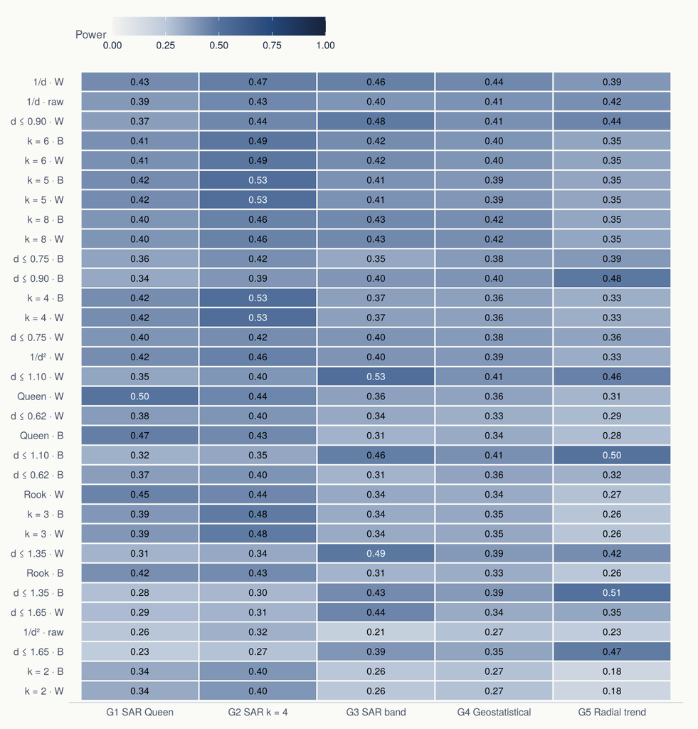

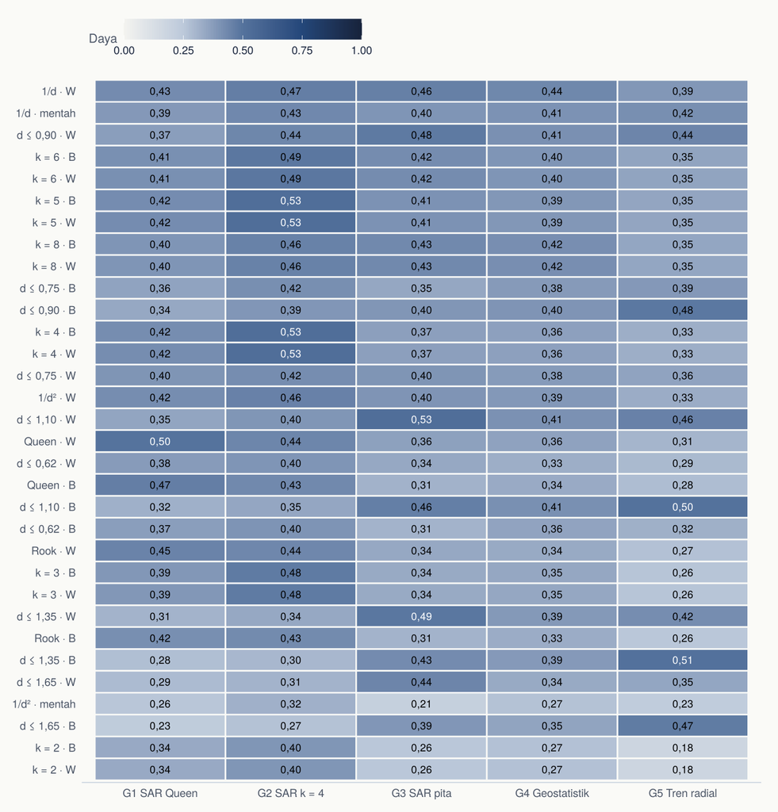

Each column is a process calibrated so that the best matrix reaches power 0.50. Darker means more power. A robust matrix stays reasonably dark in every column; a sensitive one wins in one column and fades in another.Setiap kolom adalah proses yang dikalibrasi sehingga matriks terbaik mencapai daya 0,50. Makin gelap, makin besar dayanya. Matriks robust tetap cukup gelap di setiap kolom; matriks sensitif unggul di satu kolom dan memudar di kolom lain.

Figure 15Gambar 15Power curves: the three most robust, the three most sensitive, and Queen · WKurva daya: tiga paling robust, tiga paling sensitif, dan Queen · W

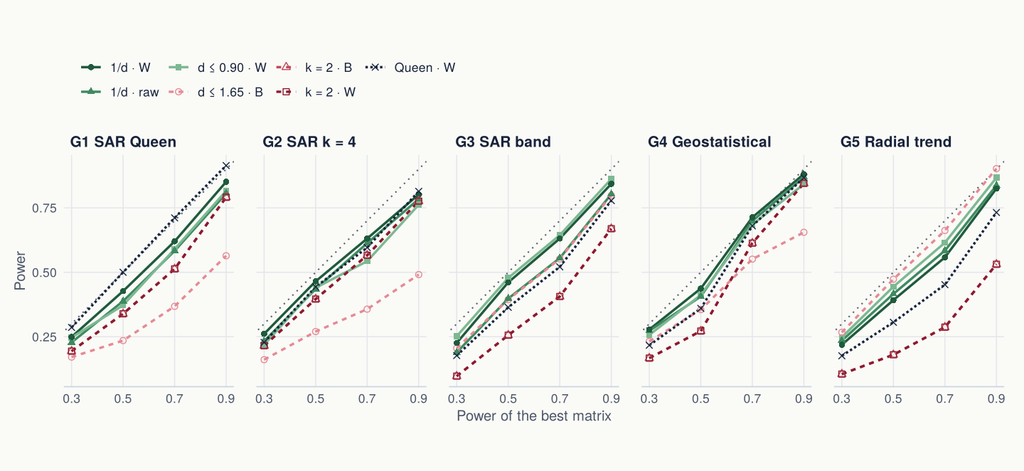

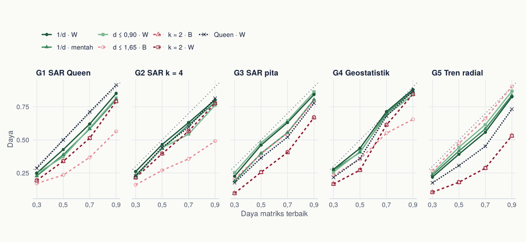

The dotted diagonal is the best matrix. The vertical gap to it is the regret. Green solid lines stay close to it in every panel; red dashed lines fall away in at least one. Queen · W is the dark dotted line.Diagonal titik-titik adalah matriks terbaik. Jarak vertikal ke garis itu adalah penyesalan. Garis hijau utuh tetap dekat di setiap panel; garis merah putus-putus menjauh setidaknya pada satu panel. Queen · W adalah garis gelap titik-titik.

Does the recommendation depend on the rule?

| Selection rule | Top three (Moran’s I) |
| --- | --- |
| Maximum regret (main rule) | 1/d · W; 1/d · raw; d ≤ 0.90 · W |
| Mean regret | 1/d · W; d ≤ 0.90 · W; k = 5 · B |
| 90th percentile of regret | 1/d · W; d ≤ 0.90 · W; 1/d · raw |
| Weak to medium patterns only (strength ≤ 0.50) | 1/d · W; d ≤ 0.90 · W; 1/d · raw |

Apakah rekomendasi bergantung pada aturan?

| Aturan pemilihan | Tiga teratas (Moran’s I) |
| --- | --- |
| Penyesalan maksimum (utama) | 1/d · W; 1/d · mentah; d ≤ 0,90 · W |
| Penyesalan rata-rata | 1/d · W; d ≤ 0,90 · W; k = 5 · B |
| Persentil ke-90 penyesalan | 1/d · W; d ≤ 0,90 · W; 1/d · mentah |
| Hanya pola lemah–sedang (tingkat ≤ 0,50) | 1/d · W; d ≤ 0,90 · W; 1/d · mentah |

Answer to the revisionJawaban atas revisi

- **Use when nothing is known: 1/d · W.** Its size is acceptable (0.044) and its maximum regret is the smallest (0.122): whatever process produced CRIME’s pattern, it loses at most that much power against the best possible matrix.
- **For Geary’s C:** k = 6 · B (maximum regret 0.097). **For both indices together:** 1/d · W, d ≤ 0.90 · W and k = 6 · B.
- **Robust** for Moran (2): 1/d · W and 1/d · raw.
- **Intermediate** (24): d ≤ 0.90 · W, k = 6 · B, k = 6 · W, k = 5 · B, k = 5 · W, k = 8 · B, k = 8 · W, d ≤ 0.75 · B, d ≤ 0.90 · B, k = 4 · B, k = 4 · W, d ≤ 0.75 · W, 1/d² · W, d ≤ 1.10 · W, Queen · W, d ≤ 0.62 · W, Queen · B, d ≤ 1.10 · B, d ≤ 0.62 · B, Rook · W, k = 3 · B, k = 3 · W, d ≤ 1.35 · W and Rook · B.
- **Sensitive** (6): d ≤ 1.35 · B, d ≤ 1.65 · W, 1/d² · raw, d ≤ 1.65 · B, k = 2 · B and k = 2 · W.
- **Robust for both indices:** none. **Sensitive for both:** d ≤ 1.35 · B, d ≤ 1.65 · W, 1/d² · raw, d ≤ 1.65 · B, k = 2 · B and k = 2 · W.
- **Queen · W**, the usual default and the reference above, is intermediate (maximum regret 0.228). It remains a sound choice when there is a substantive reason to think crime spreads across shared borders; without such a reason, it is not the safest one.
- **Dipakai bila tidak ada informasi: 1/d · W.** Ukuran ujinya wajar (0,044) dan penyesalan maksimumnya paling kecil (0,122): apa pun proses yang membentuk pola CRIME, matriks ini paling banyak kehilangan daya sebesar itu dibanding matriks terbaik.
- **Untuk Geary’s C:** k = 6 · B (penyesalan maksimum 0,097). **Untuk kedua indeks bersama:** 1/d · W, d ≤ 0,90 · W dan k = 6 · B.
- **Robust** untuk Moran (2): 1/d · W dan 1/d · mentah.
- **Menengah** (24): d ≤ 0,90 · W, k = 6 · B, k = 6 · W, k = 5 · B, k = 5 · W, k = 8 · B, k = 8 · W, d ≤ 0,75 · B, d ≤ 0,90 · B, k = 4 · B, k = 4 · W, d ≤ 0,75 · W, 1/d² · W, d ≤ 1,10 · W, Queen · W, d ≤ 0,62 · W, Queen · B, d ≤ 1,10 · B, d ≤ 0,62 · B, Rook · W, k = 3 · B, k = 3 · W, d ≤ 1,35 · W dan Rook · B.
- **Sensitif** (6): d ≤ 1,35 · B, d ≤ 1,65 · W, 1/d² · mentah, d ≤ 1,65 · B, k = 2 · B dan k = 2 · W.
- **Robust untuk kedua indeks:** tidak ada. **Sensitif untuk keduanya:** d ≤ 1,35 · B, d ≤ 1,65 · W, 1/d² · mentah, d ≤ 1,65 · B, k = 2 · B dan k = 2 · W.
- **Queen · W**, pilihan bawaan yang umum dan acuan di atas, tergolong menengah (penyesalan maksimum 0,228). Matriks ini tetap wajar bila ada alasan substantif bahwa kejahatan menyebar lewat batas wilayah; tanpa alasan itu, ia bukan pilihan paling aman.

The pattern behind the ranking: matrices in the middle (weights that decay smoothly such as $1/d$, moderate bands, $k$ around 5 to 8) still see local clusters and still see broad trends. Matrices at the extremes miss one of them: $k = 2$ is too narrow to see the downtown gradient (G5), wide binary bands are too broad to see local clusters (G1, G2), and raw $1/d^2$ is dominated by the closest pairs and loses power almost everywhere.

Pola di balik peringkat ini: matriks di tengah (bobot yang meluruh halus seperti $1/d$, pita sedang, $k$ sekitar 5 sampai 8) masih menangkap klaster lokal dan juga tren luas. Matriks di ujung kehilangan salah satunya: $k = 2$ terlalu sempit untuk menangkap gradien pusat kota (G5), pita biner yang lebar terlalu luas untuk menangkap klaster lokal (G1, G2), dan $1/d^2$ mentah didominasi pasangan terdekat sehingga dayanya rendah hampir di semua proses.

## What to do insteadYang sebaiknya dilakukan

- **Choose W before looking at the result, and write down why.Pilih W sebelum melihat hasil, dan tuliskan alasannya.**The reason should be about how the process spreads (shared borders, travel distance, a fixed radius), not about which W gives the smallest p.Alasannya harus tentang cara proses itu menyebar (batas bersama, jarak tempuh, radius tetap), bukan tentang W mana yang memberi p terkecil.
- **Without a reason, start from the minimax-regret matrix.Tanpa alasan, mulai dari matriks minimax regret.**For CRIME in Columbus that is 1/d · W. For other data, run the same simulation on your own variable; the ranking can change.Untuk CRIME di Columbus, matriks itu adalah 1/d · W. Untuk data lain, jalankan simulasi yang sama pada variabel sendiri; peringkatnya bisa berubah.
- **Report a range of W, not one.Laporkan beberapa W, bukan satu.**Show at least one matrix from each family. If the verdict changes across them, the verdict is the finding.Tampilkan setidaknya satu matriks dari setiap keluarga. Bila putusannya berubah, perubahan itulah temuannya.
- **Keep the diagonal at zero.Pastikan diagonal bernilai nol.**A non-zero wᵢᵢ inflates Moran’s I. Check it whenever W is built by hand or imported.wᵢᵢ yang tidak nol menggelembungkan Moran’s I. Periksa setiap kali W dibangun manual atau diimpor.
- **Treat LISA maps as fragile.Perlakukan peta LISA sebagai hasil yang rapuh.**Correct for 49 simultaneous tests (FDR), use conditional permutation without replacement, and show which clusters persist across matrices. A cluster seen under one W only is not evidence.Koreksi untuk 49 uji sekaligus (FDR), pakai permutasi bersyarat tanpa pengembalian, dan tunjukkan klaster mana yang bertahan di berbagai matriks. Klaster yang hanya muncul pada satu W bukan bukti.
- **Read Moran and Geary together.Baca Moran dan Geary bersama-sama.**When they disagree, look for extreme clustered values or a signal near the threshold before reporting either one.Bila keduanya tidak sepakat, periksa nilai ekstrem yang mengelompok atau sinyal yang dekat ambang sebelum melaporkan salah satunya.
- **Report the Monte Carlo uncertainty of p near 0.05.Laporkan ketidakpastian Monte Carlo pada p di sekitar 0,05.**A permutation p of 0.048 with a standard error of 0.002 is not a clear rejection.p permutasi 0,048 dengan galat baku 0,002 bukan penolakan yang tegas.

### What this means for burglaries and vehicle thefts in ColumbusArtinya bagi pencurian rumah dan kendaraan di Columbus

CRIME is one number per neighbourhood: residential burglaries and vehicle thefts **combined**, per 1,000 households, in 1980. It does not separate the two kinds of theft, and it is a rate, not a count of incidents.

The global answer holds: neighbourhoods with high theft rates sit next to other high-rate neighbourhoods. Moran’s I is significant under 32 of 32 matrices and never points to negative autocorrelation.

The local answer is a range, and it is three different counts. A neighbourhood is *significant* when its local Moran statistic survives 5% FDR correction. A *cluster* is made of High-High or Low-Low neighbourhoods; here a cluster group means High-High (or Low-Low) neighbourhoods linked through Queen contiguity to others of the same class. High-Low and Low-High neighbourhoods are *spatial outliers*, not cluster members. None of the three counts says how many thefts happened.

Under Queen · W, 4 neighbourhoods are significant: 4 High-High neighbourhoods, all in one connected group. The High-High neighbourhoods (POLYID 16, 24, 25 and 29) average 53.8 thefts per 1,000 households, against 35.1 for all 49. Under the recommended 1/d · W, 21 neighbourhoods are significant: 18 High-High neighbourhoods, all in one connected group; 3 spatial outliers (3 Low-High: POLYID 7, 9 and 22). Across all 32 matrices the number of significant neighbourhoods runs from 0 to 30; of these, High-High neighbourhoods run from 0 to 22, Low-Low from 0 to 8, and outliers from 0 to 5. 12 neighbourhoods are significant under at least half of the matrices (POLYID 11, 12, 15, 16, 18, 19, 24, 25, 26, 28, 29 and 30).

A defensible sentence for Columbus in 1980 is therefore: combined burglary and vehicle-theft rates were spatially clustered, with a High-High cluster in neighbourhoods near the central business district (under Queen · W every High-High neighbourhood is among the 12% of neighbourhoods closest to it, by DISCBD). How many neighbourhoods are flagged High-High depends on the definition of neighbour (0 to 22 across the 32 matrices), so it is reported as a range; the wider range of 0 to 30 also counts outliers and is not the size of that cluster.

CRIME adalah satu angka per lingkungan: pencurian rumah dan pencurian kendaraan **digabung**, per 1.000 rumah tangga, tahun 1980. Angka ini tidak memisahkan kedua jenis pencurian, dan merupakan tingkat (rate), bukan jumlah kejadian.

Jawaban global bertahan: lingkungan dengan tingkat pencurian tinggi bertetangga dengan lingkungan yang tingkatnya juga tinggi. Moran’s I signifikan pada 32 dari 32 matriks dan tidak pernah menunjuk autokorelasi negatif.

Jawaban lokal berupa rentang, dan terdiri atas tiga hitungan yang berbeda. Lingkungan disebut *signifikan* bila statistik Moran lokalnya bertahan setelah koreksi FDR 5%. *Klaster* terdiri atas lingkungan Tinggi-Tinggi atau Rendah-Rendah; di sini kelompok klaster berarti lingkungan Tinggi-Tinggi (atau Rendah-Rendah) yang tersambung lewat ketetanggaan Queen dengan lingkungan berkelas sama. Lingkungan Tinggi-Rendah dan Rendah-Tinggi adalah *pencilan spasial*, bukan anggota klaster. Tidak satu pun dari ketiga hitungan itu menyatakan berapa banyak pencurian yang terjadi.

Pada Queen · W, 4 lingkungan signifikan: 4 lingkungan Tinggi-Tinggi, semuanya dalam satu kelompok yang tersambung. Lingkungan Tinggi-Tinggi (POLYID 16, 24, 25 dan 29) rata-rata mencatat 53,8 pencurian per 1.000 rumah tangga, dibanding 35,1 untuk ke-49 lingkungan. Dengan matriks rekomendasi 1/d · W, 21 lingkungan signifikan: 18 lingkungan Tinggi-Tinggi, semuanya dalam satu kelompok yang tersambung; 3 pencilan spasial (3 Rendah-Tinggi: POLYID 7, 9 dan 22). Di antara ke-32 matriks, jumlah lingkungan signifikan berkisar dari 0 sampai 30; di dalamnya, lingkungan Tinggi-Tinggi berkisar dari 0 sampai 22, Rendah-Rendah dari 0 sampai 8, dan pencilan dari 0 sampai 5. Sebanyak 12 lingkungan signifikan pada setidaknya separuh matriks (POLYID 11, 12, 15, 16, 18, 19, 24, 25, 26, 28, 29 dan 30).

Kalimat yang dapat dipertanggungjawabkan untuk Columbus tahun 1980 adalah: tingkat gabungan pencurian rumah dan kendaraan mengelompok secara spasial, dengan klaster Tinggi-Tinggi di lingkungan dekat pusat bisnis kota (pada Queen · W, setiap lingkungan Tinggi-Tinggi termasuk 12% lingkungan yang paling dekat ke pusat bisnis, menurut DISCBD). Berapa lingkungan yang ditandai Tinggi-Tinggi bergantung pada definisi tetangga (0 sampai 22 di antara ke-32 matriks), sehingga dilaporkan sebagai rentang; rentang 0 sampai 30 yang lebih lebar ikut menghitung pencilan dan bukan ukuran klaster itu.

## LimitsKeterbatasan

- With $n = 49$, local tests have little power, so an empty LISA map does not prove there are no clusters.
- Robustness is measured against five chosen processes. Very different patterns, such as negative autocorrelation or distant clusters, are not covered.
- The simulation is for CRIME only. Strongly skewed variables (PLUMB, OPEN) may rank the matrices differently.
- The classification thresholds 0.15 and 0.30 are conventions, stated in advance; the rule-sensitivity table shows how much the top of the ranking depends on them.
- Distances are in arbitrary map units. Results are invariant to rescaling distances, but not to the choice of reference point (polygon centroid versus Anselin’s X/Y points), which changes some KNN neighbours.
- Dengan $n = 49$, daya uji lokal kecil, sehingga peta LISA yang kosong tidak membuktikan bahwa tidak ada klaster.
- Robustness diukur terhadap lima proses yang dipilih. Pola yang sangat berbeda, seperti autokorelasi negatif atau klaster yang berjauhan, tidak tercakup.
- Simulasi hanya untuk CRIME. Variabel yang sangat menceng (PLUMB, OPEN) bisa menghasilkan peringkat matriks yang berbeda.
- Batas klasifikasi 0,15 dan 0,30 adalah konvensi yang ditetapkan di awal; tabel kepekaan aturan menunjukkan seberapa jauh peringkat teratas bergantung padanya.
- Jarak memakai satuan peta yang arbitrer. Hasil invarian terhadap perubahan skala jarak, tetapi tidak terhadap pilihan titik acuan (centroid poligon atau titik X/Y Anselin), yang mengubah sebagian tetangga KNN.

## Reproduce and referencesReproduksi dan referensi

Knit `Columbus_Spatial_Analysis.Rmd` in RStudio, or run `rmarkdown::render("Columbus_Spatial_Analysis.Rmd", output_dir = "reports")`. One knit runs every computation (`analysis/core.Rmd`, `analysis/simulation.Rmd`), writes the CSV, PNG, RDS and JSON files in `output/`, rebuilds `dashboard_html/index.html`, and produces this page. Seeds are fixed (20261112 for the study, 20261117 for the simulation), so two knits give byte-identical CSV files. Use the EN / ID switch at the top to change the language; the link `?lang=id` opens the Indonesian version directly.

Knit `Columbus_Spatial_Analysis.Rmd` di RStudio, atau jalankan `rmarkdown::render("Columbus_Spatial_Analysis.Rmd", output_dir = "reports")`. Satu kali knit menjalankan seluruh komputasi (`analysis/core.Rmd`, `analysis/simulation.Rmd`), menulis berkas CSV, PNG, RDS, dan JSON di `output/`, membangun ulang `dashboard_html/index.html`, dan menghasilkan halaman ini. Seed ditetapkan (20261112 untuk studi, 20261117 untuk simulasi), sehingga dua kali knit menghasilkan berkas CSV yang identik byte per byte. Gunakan tombol EN / ID di atas untuk mengganti bahasa; tautan `?lang=id` langsung membuka versi bahasa Indonesia.

- Anselin, L. (1988). *Spatial Econometrics: Methods and Models*. Dordrecht: Kluwer Academic.
- Anselin, L. (1995). Local indicators of spatial association: LISA. *Geographical Analysis, 27*(2), 93–115.
- Anselin, L. (2019). A local indicator of multivariate spatial association: Extending Geary’s c. *Geographical Analysis, 51*(2), 133–150.
- Benjamini, Y., & Hochberg, Y. (1995). Controlling the false discovery rate. *Journal of the Royal Statistical Society B, 57*(1), 289–300.
- Bivand, R. S., & Wong, D. W. S. (2018). Comparing implementations of global and local indicators of spatial association. *TEST, 27*(3), 716–748.
- Bradley, J. V. (1978). Robustness? *British Journal of Mathematical and Statistical Psychology, 31*(2), 144–152.
- Cliff, A. D., & Ord, J. K. (1981). *Spatial Processes: Models and Applications*. London: Pion.
- Geary, R. C. (1954). The contiguity ratio and statistical mapping. *The Incorporated Statistician, 5*(3), 115–145.
- Moran, P. A. P. (1950). Notes on continuous stochastic phenomena. *Biometrika, 37*(1/2), 17–23.
- Ord, J. K., & Getis, A. (1995). Local spatial autocorrelation statistics. *Geographical Analysis, 27*(4), 286–306.
- Pebesma, E. (2018). Simple features for R. *The R Journal, 10*(1), 439–446.
- GeoDa Center. *Columbus Crime 1980*. https://geodacenter.github.io/data-and-lab/columbus/

**R sessionSesi R**

```
 R version 4.3.3 (2024-02-29)
Platform: x86_64-pc-linux-gnu (64-bit)
Running under: Ubuntu 24.04.5 LTS

Matrix products: default
BLAS:   /usr/lib/x86_64-linux-gnu/blas/libblas.so.3.12.0
LAPACK: /usr/lib/x86_64-linux-gnu/lapack/liblapack.so.3.12.0

locale:
 [1] LC_CTYPE=C.UTF-8       LC_NUMERIC=C           LC_TIME=C.UTF-8
 [4] LC_COLLATE=C.UTF-8     LC_MONETARY=C.UTF-8    LC_MESSAGES=C.UTF-8
 [7] LC_PAPER=C.UTF-8       LC_NAME=C              LC_ADDRESS=C
[10] LC_TELEPHONE=C         LC_MEASUREMENT=C.UTF-8 LC_IDENTIFICATION=C

time zone: Asia/Jakarta
tzcode source: system (glibc)

attached base packages:
[1] stats     graphics  grDevices utils     datasets  methods   base

other attached packages:
 [1] scales_1.3.0    knitr_1.45      jsonlite_1.8.8  patchwork_1.2.0
 [5] ggplot2_3.4.4   tidyr_1.3.1     dplyr_1.1.4     spdep_1.3-1
 [9] spData_2.3.0    sf_1.0-15

loaded via a namespace (and not attached):
 [1] gtable_0.3.4       xfun_0.41          bslib_0.6.1        lattice_0.22-5
 [5] vctrs_0.6.5        tools_4.3.3        generics_0.1.3     tibble_3.2.1
 [9] proxy_0.4-27       fansi_1.0.5        highr_0.10         pkgconfig_2.0.3
[13] Matrix_1.6-5       KernSmooth_2.23-22 lifecycle_1.0.4    compiler_4.3.3
[17] farver_2.1.1       deldir_2.0-4       textshaping_0.3.7  munsell_0.5.0
[21] htmltools_0.5.7    class_7.3-22       sass_0.4.8         yaml_2.3.8
[25] pillar_1.9.0       jquerylib_0.1.4    classInt_0.4-10    cachem_1.0.8
[29] dbscan_1.1-12      wk_0.9.1           boot_1.3-30        nlme_3.1-164
[33] mime_0.12          tidyselect_1.2.0   digest_0.6.34      purrr_1.0.2
[37] labeling_0.4.3     splines_4.3.3      fastmap_1.1.1      grid_4.3.3
[41] colorspace_2.1-0   cli_3.6.2          magrittr_2.0.3     utf8_1.2.4
[45] e1071_1.7-14       withr_2.5.0        sp_2.1-2           rmarkdown_2.25
[49] ragg_1.2.7         evaluate_0.23      mgcv_1.9-1         s2_1.1.6
[53] rlang_1.1.3        Rcpp_1.0.12        glue_1.7.0         DBI_1.2.2
[57] R6_2.5.1           systemfonts_1.0.5  units_0.8-5
```